# Msc Thesis Pt1: Describing NHCI Dropouts

- Show All Code
- Hide All Code
- View Source

Working document

Author

Affiliation

Brian ODonnell

Charité - Universitätsmedizin Berlin

This document shows work for describing NHCI patient population by attendance status.

Part two in a [separate document](https://iambodo.github.io/projects/nhci_analyses/msc_thesis_pt2_pred.html), will work with the resulting dataset to predict patient dropouts using the [tidymodels](https://www.tidymodels.org/start/case-study) workflow

For a full description of the final dataset, see section Section 7

*Goals Summary*

- Import of hypertension data from DHIS2 Line List
- Cleaning and Data quality review
- **Table1** for never returners (dropout after baseline)
- Descriptive statistics and explanation
- Add in Market Prices and Weather data as plausible predictors of dropout, with ttests

```r
 #| label: load-packages
 #| include: false
 #| echo: false

library(tidyverse)
library(table1)
library(slider)
library(skimr)
library(patchwork)
library(summarytools)
library(kableExtra)
library(effectsize)
library(RColorBrewer)
library(DT)
library(here)

palette <- brewer.pal(n = 8, name = "Dark2")

mytheme<-
  theme_minimal()+
  theme(
  panel.background = element_rect(fill = "white", color = NA),
  plot.background = element_rect(fill = "white", color = NA),
  legend.background = element_rect(fill = "white", color = NA),
  text = element_text(family="sans"),
  strip.background = element_rect(
    color = "grey70",
    linewidth = 1))

options(ggplot2.discrete.colour = palette, ggplot2.discrete.fill = palette)

theme_set(mytheme)

my_ggsave<-function(x, ...){

  ggsave(paste0(x,".png"), plot=last_plot(),
            path=here::here("figs"),
            dpi=300,
            width=ifelse(is.na(...),7, ...))

    ggsave(paste0(x,".tiff"), plot=last_plot(),
            path=here::here("figs"),
            dpi=300,
            width=ifelse(is.na(...),7, ...))
}
```

# DHIS2 Data Import and Cleaning

DHIS2 Events (Patient visits) with dates between Jan 1 2021 and June 30 2024 were [exported](https://github.com/iambodo/NHCI_exporter).

Patient IDs and other PII were removed. Age was calculated as years between DOB and Registration Date. Only those with with hypertension and consent to record data checked are included. Events that are likely test data or created outside Kano and Ogun are removed.

```r
dhis<-readr::read_csv("output_file.csv") %>%
  janitor::clean_names()


dhis_clean<-dhis %>%
  mutate(across(contains("_date"), dmy)) %>%  # convert to date everything thats a date
  mutate(across(ends_with("updated_on"), dmy)) %>%  # convert to date everything thats a date
  mutate(across(contains("mmhg"),as.double)) %>% # BP shouldnt be character
  select(!c(program_stage, geometry, longitude, latitude)) %>% #drop unused columns
  arrange(reg_id,event_date) %>% #now make a running tally for each patient visits
  group_by(reg_id) %>%
  mutate("one"=1, "appt_tally"=cumsum(one)) %>%
  select(-one) %>%
  ungroup() %>%
  rename_all(~stringr::str_replace(.,"^htn_","")) %>% # clean names
  # now extract the OU hierarchy
  separate(organisation_unit_name_hierarchy,
           into=c("Nat","State","LGA","Ward","HC","FACILITY"), sep="/") %>% # clinic hierarchy
  mutate(age=as.integer(newage)) %>% # convert age to number
  filter(!is.na(age) & age>17 & age < 130) %>% # and remove non adults
  filter(does_patient_have_hypertension=="Yes") %>% # remove those without hypertension confirmed
  filter(consent_to_record_data==1 ) %>% # and those without consent to record data
  filter(event_status %in% c("COMPLETED","ACTIVE") ) %>% #remove scheduled events
  filter(!str_detect(State,"ad ")) %>%   #and any outside K/O
  filter(!str_detect(State,"ab ")) %>%   #and any outside K/O
  filter(!str_detect(created_by,"Test")) # remove test data
```

# Data Quality Check

## Skim of data

Looking at all columns in a skim.

```r
dhis_clean %>% skimr::skim()
```

Data summary

| Name | Piped data |
| --- | --- |
| Number of rows | 165208 |
| Number of columns | 61 |
| _______________________ |  |
| Column type frequency: |  |
| character | 27 |
| Date | 5 |
| logical | 15 |
| numeric | 14 |
| ________________________ |  |
| Group variables | None |

**Variable type: character**

| skim_variable | n_missing | complete_rate | min | max | empty | n_unique | whitespace |
| --- | --- | --- | --- | --- | --- | --- | --- |
| stored_by | 49438 | 0.70 | 7 | 17 | 0 | 107 | 0 |
| created_by | 0 | 1.00 | 18 | 46 | 0 | 106 | 0 |
| last_updated_by | 0 | 1.00 | 18 | 46 | 0 | 107 | 0 |
| organisation_unit_name | 0 | 1.00 | 19 | 46 | 0 | 104 | 0 |
| Nat | 0 | 1.00 | 11 | 11 | 0 | 1 | 0 |
| State | 0 | 1.00 | 15 | 15 | 0 | 2 | 0 |
| LGA | 0 | 1.00 | 11 | 43 | 0 | 42 | 0 |
| Ward | 0 | 1.00 | 9 | 27 | 0 | 100 | 0 |
| HC | 0 | 1.00 | 11 | 47 | 0 | 105 | 0 |
| FACILITY | 156493 | 0.05 | 23 | 37 | 0 | 10 | 0 |
| program_status | 0 | 1.00 | 6 | 9 | 0 | 3 | 0 |
| event_status | 0 | 1.00 | 6 | 9 | 0 | 2 | 0 |
| organisation_unit | 0 | 1.00 | 11 | 11 | 0 | 105 | 0 |
| med_losartan | 106932 | 0.35 | 13 | 14 | 0 | 2 | 0 |
| hypertension_treated_in_the_past | 1165 | 0.99 | 10 | 23 | 0 | 2 | 0 |
| med_hydrochlorothiazide | 163799 | 0.01 | 24 | 26 | 0 | 2 | 0 |
| other_hypertension_medication | 162573 | 0.02 | 1 | 64 | 0 | 126 | 0 |
| patient_followup_status | 12318 | 0.93 | 6 | 20 | 0 | 3 | 0 |
| ncd_patient_status | 0 | 1.00 | 4 | 15 | 0 | 5 | 0 |
| days_of_medication | 137932 | 0.17 | 7 | 7 | 0 | 3 | 0 |
| does_patient_have_diabetes | 10994 | 0.93 | 2 | 3 | 0 | 2 | 0 |
| sex | 43 | 1.00 | 4 | 6 | 0 | 2 | 0 |
| relationship_to_patient | 34371 | 0.79 | 3 | 8 | 0 | 9 | 0 |
| newage | 0 | 1.00 | 2 | 3 | 0 | 96 | 0 |
| med_amlodipine | 4308 | 0.97 | 10 | 18 | 0 | 3 | 0 |
| med_telmisartan | 164758 | 0.00 | 17 | 17 | 0 | 2 | 0 |
| does_patient_have_hypertension | 0 | 1.00 | 3 | 3 | 0 | 1 | 0 |

**Variable type: Date**

| skim_variable | n_missing | complete_rate | min | max | median | n_unique |
| --- | --- | --- | --- | --- | --- | --- |
| event_date | 0 | 1 | 2021-01-01 | 2024-07-01 | 2023-01-09 | 1278 |
| last_updated_on | 0 | 1 | 2021-01-01 | 2024-07-21 | 2023-06-09 | 1276 |
| scheduled_date | 0 | 1 | 1974-06-12 | 2201-08-29 | 2023-03-13 | 1372 |
| registration_date | 0 | 1 | 1972-01-07 | 2024-07-17 | 2022-04-25 | 1324 |
| incident_date | 0 | 1 | 2003-12-08 | 2024-07-17 | 2022-06-02 | 1304 |

**Variable type: logical**

| skim_variable | n_missing | complete_rate | mean | count |
| --- | --- | --- | --- | --- |
| organisation_unit_code | 165208 | 0 | NaN | : |
| blood_sugar_reading_rbs_mgdl | 165208 | 0 | NaN | : |
| blood_sugar_unit | 165208 | 0 | NaN | : |
| history_of_heart_attack | 165208 | 0 | NaN | : |
| history_of_stroke | 165208 | 0 | NaN | : |
| blood_sugar_reading_fbs_mmoll | 165208 | 0 | NaN | : |
| blood_sugar_reading_ppbs_mmoll | 165208 | 0 | NaN | : |
| blood_sugar_reading_ppbs_mgdl | 165208 | 0 | NaN | : |
| med_glibenclamide | 165208 | 0 | NaN | : |
| other_diabetes_medication | 165207 | 0 | 0 | FAL: 1 |
| blood_sugar_reading_rbs_mmoll | 165208 | 0 | NaN | : |
| type_of_diabetes_measure | 165208 | 0 | NaN | : |
| blood_sugar_reading_hba1c | 165208 | 0 | NaN | : |
| blood_sugar_reading_fbs_mgdl | 165208 | 0 | NaN | : |
| med_metformin | 165208 | 0 | NaN | : |

**Variable type: numeric**

| skim_variable | n_missing | complete_rate | mean | sd | p0 | p25 | p50 | p75 | p100 | hist |
| --- | --- | --- | --- | --- | --- | --- | --- | --- | --- | --- |
| height_cm | 157928 | 0.04 | 86.58 | 79.29 | 0.45 | 1.6 | 148.0 | 160.0 | 758 | ▇▆▁▁▁ |
| bp_diastole_mmhg | 1300 | 0.99 | 85.28 | 239.52 | 1.00 | 76.0 | 82.0 | 90.0 | 90102 | ▇▁▁▁▁ |
| weight_kg | 157250 | 0.05 | 73.61 | 71.50 | 28.00 | 61.0 | 70.0 | 82.0 | 6298 | ▇▁▁▁▁ |
| bmi | 157923 | 0.04 | 136982.95 | 280270.71 | 0.00 | 27.0 | 38.3 | 262222.2 | 4296296 | ▇▁▁▁▁ |
| bmi_measurement | 156527 | 0.05 | 1.00 | 0.00 | 1.00 | 1.0 | 1.0 | 1.0 | 1 | ▁▁▇▁▁ |
| consent_to_send_sms_reminders | 138779 | 0.16 | 1.00 | 0.00 | 1.00 | 1.0 | 1.0 | 1.0 | 1 | ▁▁▇▁▁ |
| blood_sugar_measurement | 164697 | 0.00 | 1.00 | 0.00 | 1.00 | 1.0 | 1.0 | 1.0 | 1 | ▁▁▇▁▁ |
| bp_systole_mmhg | 700 | 1.00 | 151.44 | 1149.85 | 1.00 | 128.0 | 140.0 | 152.0 | 207120 | ▇▁▁▁▁ |
| consent_to_record_data | 0 | 1.00 | 1.00 | 0.00 | 1.00 | 1.0 | 1.0 | 1.0 | 1 | ▁▁▇▁▁ |
| reg_id | 0 | 1.00 | 16122.46 | 9360.88 | 0.00 | 7913.0 | 16113.0 | 24221.0 | 32332 | ▇▇▇▇▇ |
| has_supporter | 0 | 1.00 | 0.80 | 0.40 | 0.00 | 1.0 | 1.0 | 1.0 | 1 | ▂▁▁▁▇ |
| has_phone | 0 | 1.00 | 0.81 | 0.39 | 0.00 | 1.0 | 1.0 | 1.0 | 1 | ▂▁▁▁▇ |
| appt_tally | 0 | 1.00 | 6.26 | 5.80 | 1.00 | 2.0 | 4.0 | 9.0 | 45 | ▇▂▁▁▁ |
| age | 0 | 1.00 | 54.11 | 14.13 | 18.00 | 45.0 | 54.0 | 64.0 | 124 | ▂▇▃▁▁ |

## Clean Registration Dates

Looking at registration dates, seems some registrations are after first visit (“back data entry”).

4% of patients have later registration dates than dates of first visits.

But, registrations should always be before or on first visit date. Registration = entry to program.

This snippet overwrites registration dates to the date of first visit. The operation potentially biases Age variable, which is based on days between date of birth and registration.

**Question: How exactly are registration dates used???**

```r
# create a new registration date with rules
dhis_clean_newReg<-dhis_clean %>%
  mutate(reg_date_new=case_when(
    appt_tally==1 & registration_date<=event_date ~ registration_date,
    appt_tally==1 & registration_date>event_date ~ event_date,
    appt_tally>1 ~ NA,
    TRUE ~ NA)) %>%
  mutate(reg_date_new=if_else(as.integer(as.Date(ymd("2020-01-01"))-registration_date) > 0,
                              event_date, reg_date_new)) %>%
  group_by(reg_id) %>%
  fill(reg_date_new, .direction="down") %>%
  ungroup()

dhis_clean_newReg %>%
  select(reg_id, registration_date, reg_date_new, appt_tally, event_date) %>%
  mutate(reg_date_post_ev1=if_else(reg_date_new!=registration_date & appt_tally==1, 1, 0)) %>%
  filter(appt_tally==1) %>%
  count(reg_date_post_ev1) %>%
  mutate(percent=n/sum(n))
```

```
# A tibble: 2 × 3
  reg_date_post_ev1     n percent
              <dbl> <int>   <dbl>
1                 0 29554  0.962
2                 1  1157  0.0377
```

```r
# Now rewrite the clean dhis dataset.
# Remove unneeded columns and create days since entry
dhis_clean<-dhis_clean_newReg %>%
  mutate(registration_date=reg_date_new) %>%
    mutate(days_since_entry=as.double(event_date-registration_date)) %>%  #days since entry
  select(-reg_date_new) %>%
  janitor::remove_empty(which = "cols") # remove all unnecessary columns
```

```r
# dhis_clean<-dhis_clean %>% filter(registration_date >= ymd("2021-01-01"))
```

Notice the dates and years of events, looks correct.

```r
dhis_clean %>%
  select(event_date, reg_id) %>%
  distinct() %>%
  mutate(year=lubridate::year(as.Date(event_date))) %>%
  count(year) %>%   kable() %>% kableExtra::kable_styling()
```

| year | n |
| --- | --- |
| 2021 | 24643 |
| 2022 | 55985 |
| 2023 | 57631 |
| 2024 | 25452 |

## Zero ending values

And, 30% of all “Age at Registration” end in 0. (36% of SBPs do as well).

HCWs were using the DOB attribute as An ESTIMATE of Age, instead of as a true DOB. A feature of DHIS2 enables this estimation.

But between the incorrect registration date and using Age/DoB as an estimate, the Age Variable is imprecise and has unknown measurement error.

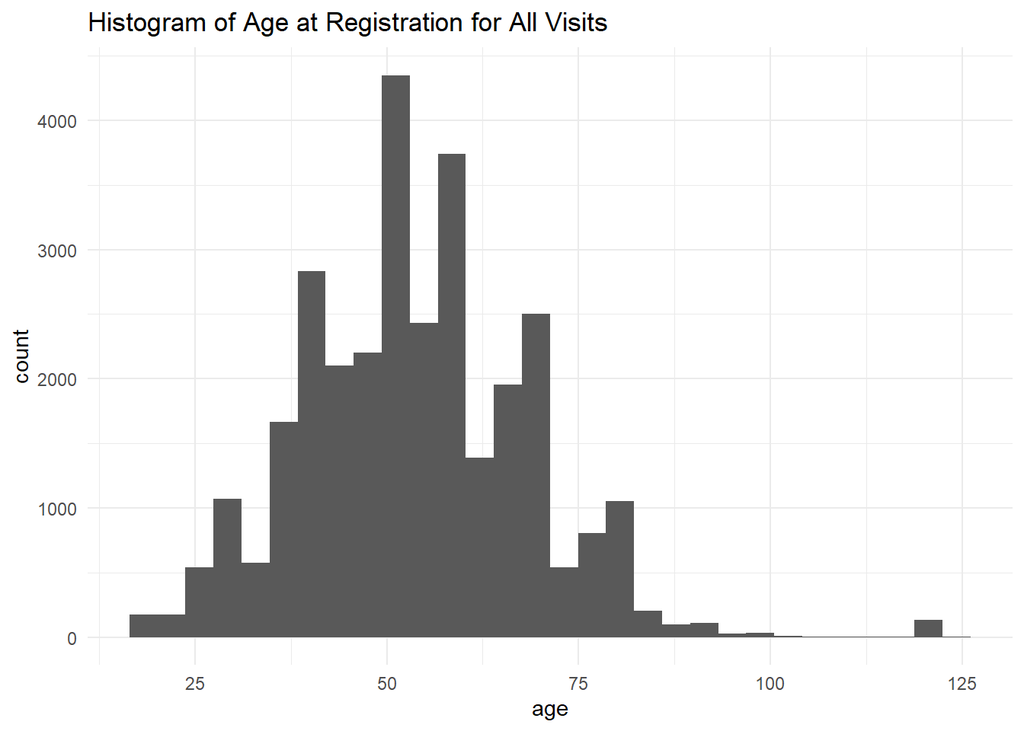

```r
dhis_clean %>%
  select(newage, reg_id) %>%
    distinct() %>%
  mutate(age=as.integer(newage)) %>%
  select(age) %>%
  filter(age>0) %>%
## !!!! 30% of all Ages end in 0!!!!
## Measurement error by entering age instead of DOB
  # mutate(age_zero=if_else(age %% 10==0, 1, 0)) %>%
  # count(age_zero) %>%
  # mutate(per=n/sum(n))
  ggplot() +
  geom_histogram(aes(x=age)) +
  labs(title="Histogram of Age at Registration for All Visits")
```

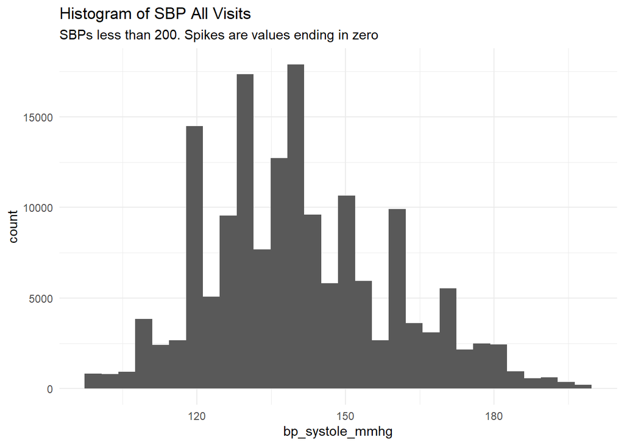

```r
dhis_clean %>%
  mutate(age_zero=if_else(bp_systole_mmhg %% 10==0, 1, 0)) %>%
  filter(99 < bp_systole_mmhg & bp_systole_mmhg<200) %>%
  # count(age_zero) %>%
  # mutate(per=n/sum(n))
  ggplot() +
  geom_histogram(aes(x=bp_systole_mmhg)) +
  labs(title="Histogram of SBP All Visits",
       subtitle = "SBPs less than 200. Spikes are values ending in zero")
```

## Duplicate events?

It looks like a number of visits occur on the same day for many patients.

```r
## Found duplicate events!!!
tots_d <- dhis_clean %>%
  mutate(reg_visit_id=paste0(reg_id,"_",appt_tally)) %>%
  group_by(reg_id) %>%
  mutate(prev_event_date = lag(event_date, n=1, order_by=event_date)) %>%
  mutate(lead_event_date = lead(event_date, n=1, order_by=event_date)) %>%
  ungroup()


### highlight them as dupes
dupes <- tots_d %>%
  # select(reg_id, event_date, prev_event_date, organisation_unit_name) %>%
  # ungroup() %>%
  mutate(dupe=if_else(event_date==prev_event_date | event_date==lead_event_date, 1, 0)) %>%
  group_by(reg_id) %>%
  # fill(dupe, .direction="down") %>%
  filter(dupe==1) %>% arrange(reg_id,event_date)



## TRUE dupes also have identical dates except "last updated" date
dupes_true <- dupes %>%
  ungroup() %>%
  select(!c(lead_event_date, prev_event_date, last_updated_by)) %>%
  ## this only keeps rows that are identical except for the appointment tally and visit id
  janitor::get_dupes(!c(appt_tally, reg_visit_id))

print(paste0("total patients ", length(unique(tots_d$reg_id))))
```

```
[1] "total patients 30714"
```

```r
print(paste0("patient records with dupe events ", length(unique(dupes$reg_id))))
```

```
[1] "patient records with dupe events 1122"
```

```r
print(paste0("duped events ", length(dupes$reg_id)))
```

```
[1] "duped events 2856"
```

```r
print(paste0("patient records with true dupe events on same day ", length(unique(dupes_true$reg_id))))
```

```
[1] "patient records with true dupe events on same day 151"
```

```r
# length(unique(dhis_subset$reg_id))


# Only the first of all "true dupe" events should still be kept!
dupes_true_extras<-dupes_true %>%
      group_by(reg_id) %>%
      mutate("one"=1, "dupe_visit_id"=cumsum(one)) %>%
      select(-one) %>%
      select(reg_id,reg_visit_id, dupe_visit_id) %>%
      filter(dupe_visit_id>1)

## The new dataset with totals is called tots and has removed the "true dupe" visits
tots <-tots_d %>%
      anti_join(dupes_true_extras, by="reg_visit_id")

# (1122-188)/length(unique(dhis_clean$reg_id))
```

1122 of 30714 patient records reported at least one pair of visits on the same day ( 2856 events total). Of these, 151 patients had “true duplicates” where data reported within each visit was identical.

NEXT STEP for dupes would be to pivot longer, then find those variables that are NOT identical within Dupes

This table shows us the *FIELDS* which do not match within a pair of duplicated events for the same registration.

```r
d_long <-dupes %>%
  group_by(reg_id) %>%
  arrange(event_date, last_updated_on) %>%
  mutate("one"=1, "dupe_id"=cumsum(one)) %>%
  select(-one) %>%
  ungroup()

dupe_clash <-d_long %>%
    filter(dupe_id<3) %>% # just those regs with exactly 2 dupe events
    mutate(across(everything(), as.character)) %>% # no dates or appt counts
    select(!ends_with("_date"), -appt_tally, -reg_visit_id) %>%
    pivot_longer(!c(reg_id, dupe_id), names_to="var",values_to="value") %>%
    pivot_wider(names_from=dupe_id,
                names_prefix = "dupe_",
                values_from=c(value)) %>%
    # filter(!is.na(dupe_1)) %>%
    mutate(match=case_when(
      is.na(dupe_1) & is.na(dupe_2) ~ TRUE,
      dupe_1==dupe_2 ~ TRUE,
      TRUE ~ FALSE)) %>%
    filter(match==FALSE) %>%
    arrange(reg_id)

dupe_clash %>%
  count(var, sort=T)
```

```
# A tibble: 24 × 2
   var                    n
   <chr>              <int>
 1 last_updated_on      516
 2 bp_diastole_mmhg     401
 3 bp_systole_mmhg      395
 4 med_losartan         152
 5 med_amlodipine       151
 6 event_status          89
 7 days_of_medication    76
 8 created_by            66
 9 stored_by             65
10 bmi_measurement       37
# ℹ 14 more rows
```

Last Updated date *could* be helpful for deduping, same as stored_by, created_by, and event status (COMPLETED locks the values, so if there is an error there, another one could be made on same place).

But if those are not obvious for which one should be used, then we would use the non null BP.

Two visits on same day with non null BP values will be difficult to merge automatically.

*THE RULES FOR MERGING TWO PATIENT VISITS ON SAME DATE*

1. If one of the events does not have a BP reading, all values in the event with BP reading take priority (if any duped event has all BP NA, its removed from dataset).
2. ACTIVE status events are generally opened after COMPLETED events to make a change. If its the only ACTIVE event that date, use this event. Priority = 3 (max)
3. If other clashes, count the number of nulls for medication. If one of the events has least med nulls, then use that event. Priority = 2
4. If still cannot reconcile, use the first event by date last updated (or, if last updated on same day, random). Priority = 1

```r
# this chunk will apply the priority rules to flag priority events
d_long_priorities <- d_long %>%
    filter(!is.na(bp_diastole_mmhg) & !is.na(bp_systole_mmhg)) %>%
    group_by(reg_id, event_date, event_status) %>%
    mutate(dupes_evs_with_this_status=n()) %>% ungroup() %>%
    mutate(dupe_meds_null_count = rowSums(is.na(across(contains("med"))))) %>%
    group_by(reg_id, event_date) %>%
    mutate(dupes_evs_mostMeds=min(dupe_meds_null_count)) %>%
    mutate(dupes_evs_withMedCount=n()) %>%
      mutate(dupe_id_priority =
      case_when(
        dupes_evs_with_this_status==1 & event_status=="ACTIVE" ~ 3,
        dupes_evs_mostMeds==dupe_meds_null_count & dupes_evs_withMedCount==1 ~ 2,
        dupe_id==min(dupe_id) ~ 1,
          TRUE ~ 0
        ) ) %>% ungroup()

# WE WANT TO KEEP ALL THESE AND REMOVE OTHER DUPES
d_long_keepers <-d_long_priorities %>%
       group_by(reg_id, event_date) %>%
       filter(dupe_id_priority==max(dupe_id_priority)) %>% ungroup()

d_long_remove <- d_long %>%
  anti_join(d_long_keepers, by="reg_visit_id")

# d_long_remove %>% colnames()

d_long_keepers %>%
  janitor::tabyl(dupe_id_priority) %>%
  kable() %>% kableExtra::kable_styling()
```

| dupe_id_priority | n | percent |
| --- | --- | --- |
| 1 | 1195 | 0.8871566 |
| 2 | 104 | 0.0772086 |
| 3 | 48 | 0.0356347 |

We remove 1509 events from the main dataset and then recreate the appointment tally and visit IDs.

```r
tots<-tots %>%
  anti_join(d_long_remove, by="reg_visit_id") %>%
# REDO THE APPT TALLY AND REG_VISIT_ID now that the dupes have been removed
  arrange(reg_id,event_date) %>% #make a running tally for each patient visits
  group_by(reg_id) %>%
  mutate("one"=1, "appt_tally"=cumsum(one)) %>%
  select(-one) %>% ungroup() %>%
  mutate(reg_visit_id=paste0(reg_id,"_",appt_tally)) %>%
  group_by(reg_id) %>%
  add_count(name="total_patient_visits") %>% # counter for total patients visits
  mutate(prev_event_date = lag(event_date, n=1, order_by=event_date)) %>%
  mutate(lead_event_date = lead(event_date, n=1, order_by=event_date)) %>%
  ungroup() #and need to add new lead lag dates
```

# Description

## Table 1 Zero Followup Visits After Baseline

Process it for the **Table1** all registrations up to *April 1 2024.*

Thus all patients have at least 90 days for a follow up Visit after Baseline Visit.

“>=1 Visits Post Baseline” here means at least 1 visit occurs later. The second visit can be within or after 90 days from baseline.

```r
dhis_subset <- tots %>%
    filter(registration_date >= dmy("01-01-2021")) %>%
    filter(registration_date <= dmy("01-04-2024"))

dhis_table <- dhis_subset %>%
    mutate(patient_returned=if_else(total_patient_visits>1,
                                    ">=1 Visits Post Baseline",
                                    "0 Visits Post Baseline"
                                    )) %>%
    mutate(bp_systole_mmhg=if_else(bp_systole_mmhg>400, 400, bp_systole_mmhg)) %>%
    mutate(sbp_level =
      case_when(
        bp_systole_mmhg >= 400 |  bp_systole_mmhg < 50 ~ "error (>300 or < 50)",
        bp_systole_mmhg >= 180 & bp_systole_mmhg < 400  ~ "emergency [180-300)",
        bp_systole_mmhg >= 140 & bp_systole_mmhg < 180  ~ "very high [140-180)",
        bp_systole_mmhg >= 120 & bp_systole_mmhg < 140 ~ "high or elevated (120-140)",
        is.na(bp_systole_mmhg) ~ NA,
        TRUE ~ "normal")
    ) %>%
  mutate(sbp_level=fct_relevel(sbp_level,
                              c("normal","high or elevated (120-140)",
                               "very high [140-180)","emergency [180-300)",
                               "error (>300 or < 50)"))) %>%
  mutate(has_diabetes=as.factor(does_patient_have_diabetes)) %>%
  mutate(has_phone=as.factor(has_phone)) %>%
  mutate(has_supporter=as.factor(has_supporter)) %>%
  mutate(age_group = as.factor(cut(age,
                         breaks = c(0, 30, 45, 60, 75, 110, 100000),
                         include.lowest = T,
                         labels = c("Other", "30-44","45-59",
                                    "60-74", "75-110", "Other")))) %>%
  mutate(age_group=fct_shift(age_group, n= 1)) %>%
  select(patient_returned, State, sex, age, age_group, appt_tally,
         "sbp_baseline"=sbp_level, bp_systole_mmhg,
         "previous_htn_treated"=hypertension_treated_in_the_past,
         "amlodipine_baseline"=med_amlodipine,
         has_phone, has_supporter, has_diabetes,days_of_medication,
         total_patient_visits) %>%
  filter(appt_tally==1)


## Write it to RDS for the manuscript
write_rds(dhis_table, file=here::here("data","dhis_table.rds"))


tab1<-table1::table1(~ sex + State + age + age_group + previous_htn_treated +
                 sbp_baseline + bp_systole_mmhg + amlodipine_baseline + has_phone +
                 has_supporter + has_diabetes +days_of_medication + total_patient_visits
                 | factor(patient_returned),
               data=dhis_table)

# t1flex(tab1)
tab1
```

|  | >=1 Visits Post Baseline (N=21183) | 0 Visits Post Baseline (N=7044) | Overall (N=28227) |
| --- | --- | --- | --- |
| sex |  |  |  |
| Female | 16005 (75.6%) | 5032 (71.4%) | 21037 (74.5%) |
| Male | 5171 (24.4%) | 2008 (28.5%) | 7179 (25.4%) |
| Missing | 7 (0.0%) | 4 (0.1%) | 11 (0.0%) |
| State |  |  |  |
| kn Kano State | 13042 (61.6%) | 2910 (41.3%) | 15952 (56.5%) |
| og Ogun State | 8141 (38.4%) | 4134 (58.7%) | 12275 (43.5%) |
| age |  |  |  |
| Mean (SD) | 53.7 (14.6) | 53.9 (15.6) | 53.8 (14.8) |
| Median [Min, Max] | 53.0 [18.0, 124] | 53.0 [18.0, 122] | 53.0 [18.0, 124] |
| age_group |  |  |  |
| 30-44 | 5111 (24.1%) | 1682 (23.9%) | 6793 (24.1%) |
| 45-59 | 8738 (41.3%) | 2926 (41.5%) | 11664 (41.3%) |
| 60-74 | 4755 (22.4%) | 1494 (21.2%) | 6249 (22.1%) |
| 75-110 | 1253 (5.9%) | 451 (6.4%) | 1704 (6.0%) |
| Other | 1326 (6.3%) | 491 (7.0%) | 1817 (6.4%) |
| previous_htn_treated |  |  |  |
| First time | 17400 (82.1%) | 5632 (80.0%) | 23032 (81.6%) |
| Was treated in the past | 3632 (17.1%) | 1323 (18.8%) | 4955 (17.6%) |
| Missing | 151 (0.7%) | 89 (1.3%) | 240 (0.9%) |
| sbp_baseline |  |  |  |
| normal | 182 (0.9%) | 43 (0.6%) | 225 (0.8%) |
| high or elevated (120-140) | 1293 (6.1%) | 302 (4.3%) | 1595 (5.7%) |
| very high [140-180) | 17547 (82.8%) | 5701 (80.9%) | 23248 (82.4%) |
| emergency [180-300) | 2082 (9.8%) | 951 (13.5%) | 3033 (10.7%) |
| error (>300 or < 50) | 13 (0.1%) | 5 (0.1%) | 18 (0.1%) |
| Missing | 66 (0.3%) | 42 (0.6%) | 108 (0.4%) |
| bp_systole_mmhg |  |  |  |
| Mean (SD) | 158 (17.9) | 161 (18.8) | 159 (18.1) |
| Median [Min, Max] | 158 [14.0, 400] | 160 [14.0, 400] | 159 [14.0, 400] |
| Missing | 66 (0.3%) | 42 (0.6%) | 108 (0.4%) |
| amlodipine_baseline |  |  |  |
| Amlodipine 10mg OD | 1802 (8.5%) | 802 (11.4%) | 2604 (9.2%) |
| Amlodipine 5mg OD | 19175 (90.5%) | 6158 (87.4%) | 25333 (89.7%) |
| Other drug | 3 (0.0%) | 0 (0%) | 3 (0.0%) |
| Missing | 203 (1.0%) | 84 (1.2%) | 287 (1.0%) |
| has_phone |  |  |  |
| 0 | 3994 (18.9%) | 1359 (19.3%) | 5353 (19.0%) |
| 1 | 17189 (81.1%) | 5685 (80.7%) | 22874 (81.0%) |
| has_supporter |  |  |  |
| 0 | 4217 (19.9%) | 1593 (22.6%) | 5810 (20.6%) |
| 1 | 16966 (80.1%) | 5451 (77.4%) | 22417 (79.4%) |
| has_diabetes |  |  |  |
| No | 19050 (89.9%) | 6253 (88.8%) | 25303 (89.6%) |
| Yes | 461 (2.2%) | 142 (2.0%) | 603 (2.1%) |
| Missing | 1672 (7.9%) | 649 (9.2%) | 2321 (8.2%) |
| days_of_medication |  |  |  |
| 30 days | 2395 (11.3%) | 1021 (14.5%) | 3416 (12.1%) |
| 60 days | 27 (0.1%) | 14 (0.2%) | 41 (0.1%) |
| 90 days | 0 (0%) | 1 (0.0%) | 1 (0.0%) |
| Missing | 18761 (88.6%) | 6008 (85.3%) | 24769 (87.7%) |
| total_patient_visits |  |  |  |
| Mean (SD) | 6.87 (5.72) | 1.00 (0) | 5.40 (5.57) |
| Median [Min, Max] | 5.00 [2.00, 45.0] | 1.00 [1.00, 1.00] | 3.00 [1.00, 45.0] |

Count of patients returned after first visit.

```r
dhis_table %>%
  count(patient_returned) %>%
  mutate(pt=n/sum(n))
```

```
# A tibble: 2 × 3
  patient_returned             n    pt
  <chr>                    <int> <dbl>
1 0 Visits Post Baseline    7044 0.250
2 >=1 Visits Post Baseline 21183 0.750
```

### Visits per patient

Explore the data. Start by counting the number of visits per patient.

This shows patients registered before a given date.

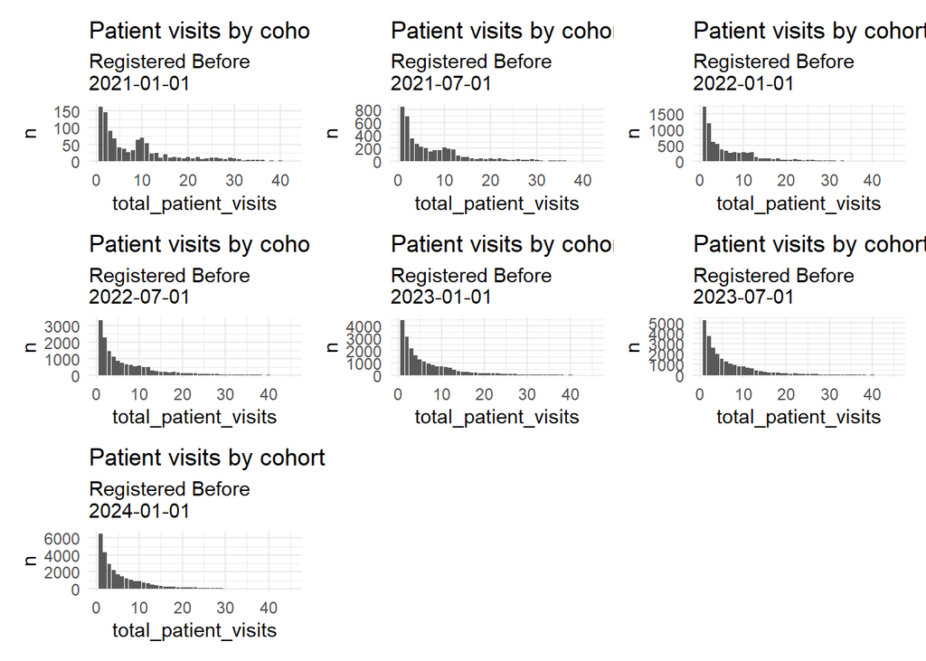

```r
tots_small <-tots %>%
  filter(registration_date >= ymd("2021-01-01")) %>%
  select(reg_id, total_patient_visits) %>%
  unique()


seq_visits<-seq(ymd('2021-01-01'),ymd('2024-01-01'), by = '6 months')


seq_func<-function(vec){
  tots %>%
  ungroup() %>%
  filter(registration_date <= ymd(vec)) %>%
  select(reg_id, total_patient_visits) %>%
  unique() %>%
  count(total_patient_visits) %>%
  ggplot() +
  geom_col(aes(y=n, x=total_patient_visits)) +
    labs(title="Patient visits by cohort",
      subtitle=str_wrap(paste0("Registered Before ",
                               as.character(vec)),20))
}

patchwork::wrap_plots(lapply(seq_visits, seq_func))
```

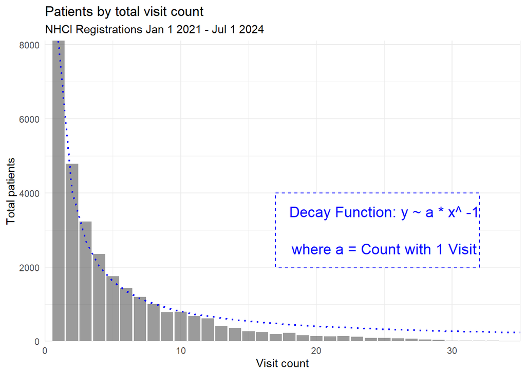

```r
df<-data.frame(x=seq(1:40))
df$y<-8100*df$x^-1



tots_small %>%
  count(total_patient_visits) %>%
  left_join(df, by=c("total_patient_visits"="x")) %>%
  ggplot(aes(x=total_patient_visits)) +
  geom_col(aes(y=n), alpha=0.6) +
  geom_line(aes(y=y), color="blue", linetype=3, linewidth=0.8) +
  scale_x_continuous(limits=c(0,35)) +
  labs(title="Patients by total visit count",
       subtitle="NHCI Registrations Jan 1 2021 - Jul 1 2024",
       x="Visit count",
       y="Total patients") +
  annotate("rect", xmin=17, xmax=32, ymin=2000, ymax=4000, color="blue",fill="white", linetype=2) +
  annotate("text", x=25, y=3500, label="Decay Function: y ~ a * x^ -1", size=5, color="blue") +
  annotate("text", x=25, y=2500, label="where a = Count with 1 Visit", size=5, color="blue") +
  expand_limits(x = 0, y = 0) +
    coord_cartesian(expand = FALSE, clip = "off")
```

```r
my_ggsave("fig1_visitCounts",12)
```

```r
count(tots_small, total_patient_visits) %>%
  ungroup() %>%
  mutate(percent=round(100*(n/sum(n)),4)) %>% DT::datatable(rownames = FALSE)
```

| total_patient_visits | n | percent |
| --- | --- | --- |
| 1 | 8105 | 27.3199 |
| 2 | 4792 | 16.1526 |
| 3 | 3230 | 10.8875 |
| 4 | 2359 | 7.9516 |
| 5 | 1755 | 5.9157 |
| 6 | 1443 | 4.864 |
| 7 | 1192 | 4.0179 |
| 8 | 1010 | 3.4045 |
| 9 | 787 | 2.6528 |
| 10 | 800 | 2.6966 |

[output cut: 32 more lines]

```r
tots_small %>%
      mutate(count_level =
        case_when(
          total_patient_visits==1 ~ "01 visit",
          total_patient_visits>=2 & total_patient_visits < 4  ~ "02-03 visits",
          total_patient_visits>=4 & total_patient_visits < 11  ~ "04-10 visits",
          total_patient_visits>=4 & total_patient_visits < 11  ~ "04-10 visits",
          total_patient_visits>=11 & total_patient_visits < 46  ~ "11-45 visits",
          TRUE ~ NA
        )
      ) %>%
    count(count_level) %>%
    mutate(percent=100*(n/sum(n))) %>% kable() %>% kableExtra::kable_styling()
```

| count_level | n | percent |
| --- | --- | --- |
| 01 visit | 8105 | 27.31992 |
| 02-03 visits | 8022 | 27.04015 |
| 04-10 visits | 9346 | 31.50302 |
| 11-45 visits | 4194 | 14.13692 |

```r
#72816/126422
## top 20% of attendees by visit count, attended 58% of all visits.
```

Investigate NCD Patient Status variable (patient follow up tracker..)

```r
# tots %>%
#   distinct(reg_id, ncd_patient_status) %>%
#   count(ncd_patient_status)

tots %>%
  count(ncd_patient_status) %>%
  mutate(pct=round(n/sum(n),4)*100) %>% kable() %>% kableExtra::kable_styling()
```

| ncd_patient_status | n | pct |
| --- | --- | --- |
| Active record | 162166 | 99.07 |
| Died | 457 | 0.28 |
| Inactive record | 433 | 0.26 |
| Transferred | 569 | 0.35 |
| Unresponsive | 69 | 0.04 |

```r
# length(unique(tots$reg_id))

# 1100/30704
```

Narrow in on registrations after jan 1 2023, can see a dropoff of attendance by sex.

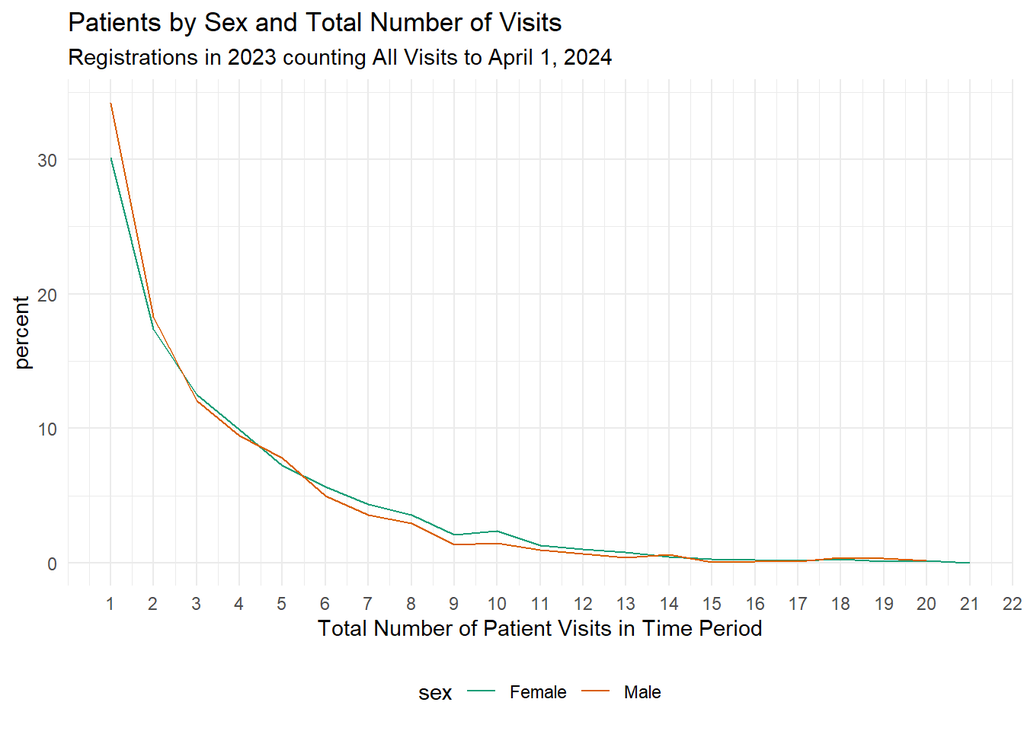

```r
tots %>%
  ungroup %>%
  arrange(desc(registration_date)) %>%
  filter(registration_date>=ymd("2023-01-01") &
         registration_date<ymd("2024-01-01") ) %>%
  filter(!is.na(sex)) %>%
    # mutate(n_group =
    #   case_when(
    #     total_patient_visits==1 ~ "01 (Entry)",
    #     total_patient_visits==2 ~ "02",
    #     total_patient_visits >1 & total_patient_visits<=5 ~ "03-06",
    #     total_patient_visits >5 & total_patient_visits<=11 ~ "07-11",
    #     TRUE ~ "12+"
    #   )
    # ) %>%
  ungroup() %>%
  filter(total_patient_visits==appt_tally & appt_tally<25) %>%
  group_by(sex, appt_tally) %>%
  summarise(count_by_ngroup=n()) %>%
  mutate(percent= prop.table(count_by_ngroup)*100) %>%
  mutate(cumulative_percent=cumsum(percent)) %>%
  ungroup() %>%
  as_tibble() %>%
  ggplot()+
  geom_line(aes(x=appt_tally,y=percent, color=sex)) +
  # geom_col(aes(x=appt_tally,y=percent, fill=sex), position="dodge") +
  # facet_grid(~sex, scales="fixed") +
  labs(title="Patients by Sex and Total Number of Visits",
       subtitle="Registrations in 2023 counting All Visits to April 1, 2024",
       x="Total Number of Patient Visits in Time Period")+
  # theme_classic()+
  theme(legend.position = "bottom") +
  scale_x_continuous(breaks = seq(1, 22, by = 1))
```

```r
tots %>% count(LGA) %>% nrow()
```

```
[1] 42
```

### Monthly patient load per clinic

```r
dhis_pts_per_month<-tots %>%
  mutate(appt_month=lubridate::month(event_date)) %>% # transform to month
  group_by(appt_month, organisation_unit) %>%
  summarize(patients=n_distinct(reg_id),
            appts=n()) %>%
  ungroup() %>%
  mutate(appt_patient_ratio=appts/patients)

dhis_pts_per_month %>%
  summarytools::descr()
```

```
Descriptive Statistics
dhis_pts_per_month
N: 1242

                    appt_month   appt_patient_ratio     appts   patients
----------------- ------------ -------------------- --------- ----------
             Mean         6.49                 1.21    131.80     103.45
          Std.Dev         3.45                 0.16    183.67     136.95
              Min         1.00                 1.00      1.00       1.00
               Q1         3.00                 1.10     41.00      35.00
           Median         6.00                 1.18     74.00      61.00
               Q3         9.00                 1.29    131.00     108.00
              Max        12.00                 2.08   1287.00     990.00
              MAD         4.45                 0.13     57.82      45.96
              IQR         5.75                 0.19     90.00      72.75
               CV         0.53                 0.13      1.39       1.32
         Skewness         0.00                 1.40      3.33       3.46
      SE.Skewness         0.07                 0.07      0.07       0.07
         Kurtosis        -1.22                 3.24     12.12      13.64
          N.Valid      1242.00              1242.00   1242.00    1242.00
        Pct.Valid       100.00               100.00    100.00     100.00
```

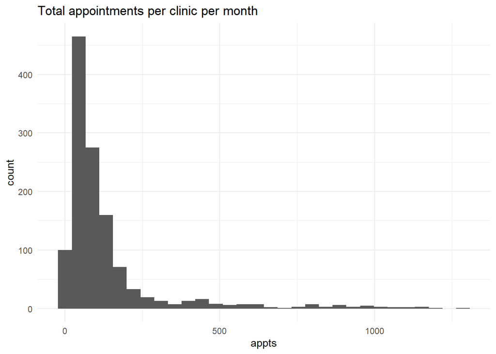

```r
# %>% summarize(patient_avg=mean(patients),
#             appt_avg=mean(appts))

dhis_pts_per_month %>%
  ggplot()+
  geom_histogram(aes(x=appts),bins=30) +
  labs(title="Total appointments per clinic per month")
```

### Days & months enrolled per patient

Days enrolled per patient = Days since entry at latest event + 90

```r
dpv<-tots %>%
  select(reg_id, appt_tally, total_patient_visits, registration_date,
         event_date, days_since_entry) %>%
  filter(appt_tally==total_patient_visits & days_since_entry>=0) %>%
  mutate(days_tracked=days_since_entry+90) %>%
  mutate(patient_days_per_visit=days_tracked/total_patient_visits)

summary(dpv$patient_days_per_visit)
```

```
    Min.  1st Qu.   Median     Mean  3rd Qu.     Max.
   5.294   58.000   90.000   94.394   90.600 1370.000
```

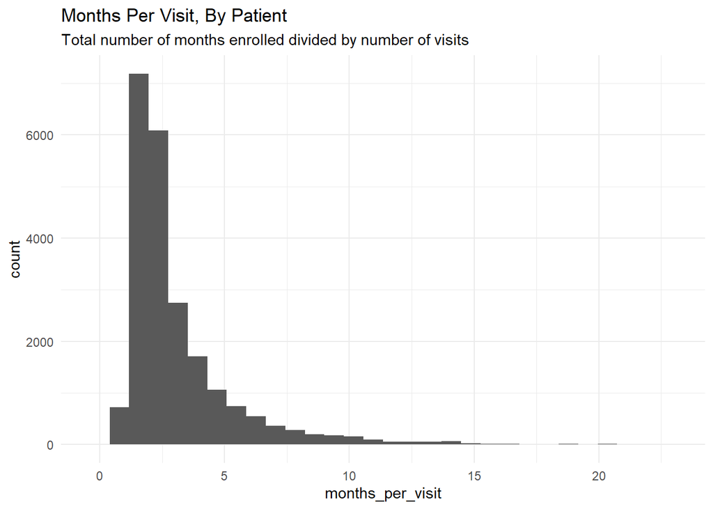

```r
# tots %>%
#   filter(total_patient_visits>40) %>% View()

dpv %>%
  mutate(days_enrolled=if_else(total_patient_visits==appt_tally,
                               event_date-registration_date, NA)) %>%
  filter(!is.na(days_enrolled) & total_patient_visits>1) %>%
  # filter(patient_days_per_visit>=0 & patient_days_per_visit< 91) %>%
  mutate(months_per_visit=patient_days_per_visit/30) %>%
  ggplot() +
  geom_histogram(aes(x=months_per_visit)) +
  labs(title="Months Per Visit, By Patient",
       subtitle="Total number of months enrolled divided by number of visits")
```

Cumulative density of days since Last visit

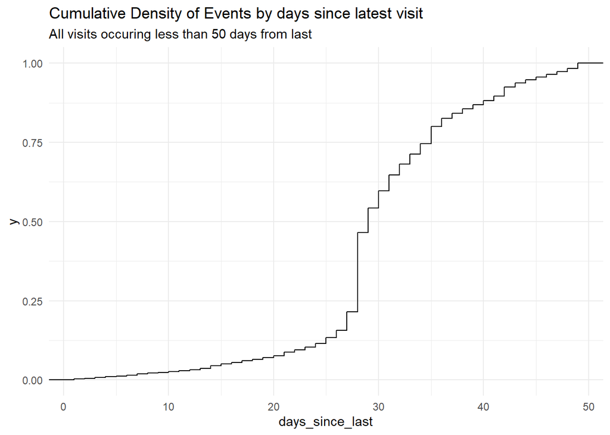

```r
tots %>%
  filter(appt_tally!=1) %>%
  mutate(days_since_last=as.integer(event_date-prev_event_date)) %>%
  filter(days_since_last<50) %>%
  # count(days_since_last) %>%
  ggplot(aes(x=days_since_last)) +
  geom_step(aes(y=after_stat(y)),stat="ecdf") +
  labs(title="Cumulative Density of Events by days since latest visit",
       subtitle = "All visits occuring less than 50 days from last")
```

```r
#
#   ggplot() +
#   geom_histogram(aes(x=days_since_last))
```

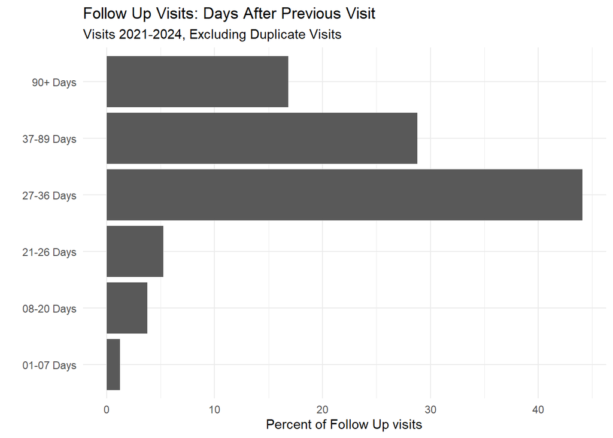

```r
tots %>%
    filter(appt_tally>1) %>%
      mutate(days_since_last=event_date-prev_event_date) %>%
  # filter(days_since_last>7) %>%
      mutate(days_since_level =
        case_when(
          days_since_last ==0 ~ "_Same Day",
          days_since_last>=1 & days_since_last < 8  ~ "01-07 Days",
          days_since_last>=8 & days_since_last < 21  ~ "08-20 Days",
          days_since_last>=21 & days_since_last < 27  ~ "21-26 Days",
          days_since_last>=27 & days_since_last < 37  ~ "27-36 Days",
          days_since_last>=37 & days_since_last < 90  ~ "37-89 Days",
          days_since_last>=90  ~ "90+ Days",
          TRUE ~ "_Same Day"
        )
      ) %>%
    count(days_since_level) %>%
    mutate(percent=100*(n/sum(n))) %>%
    ggplot(aes(x=days_since_level,y=percent))+
    geom_col() +

    # geom_text(aes(label = round(percent,2)), color="white") +
    labs(title="Follow Up Visits: Days After Previous Visit",
         subtitle="Visits 2021-2024, Excluding Duplicate Visits",
         x="",y="Percent of Follow Up visits") +coord_flip()
```

## Define the outcome event: Attrition

- No return visit after entry visit
- **No return within 1-90 days of a visit (Loose Window)**
- No return within 1-37 days of any visit (Strict Window)
- No return within 365 days of latest visit (Original Window)

### Patient status

Here we check what patient statuses follow the latest visit.

```r
tots %>%
  filter(appt_tally==total_patient_visits) %>%
  count(patient_followup_status, ncd_patient_status)
```

```
# A tibble: 19 × 3
   patient_followup_status ncd_patient_status     n
   <chr>                   <chr>              <int>
 1 Called                  Active record        143
 2 Called                  Died                   2
 3 Called                  Inactive record        9
 4 Called                  Transferred            4
 5 Overdue Pending Call    Active record      24293
 6 Overdue Pending Call    Died                  72
 7 Overdue Pending Call    Inactive record      139
 8 Overdue Pending Call    Transferred          116
 9 Overdue Pending Call    Unresponsive          20
10 Upcoming visit          Active record       2535
11 Upcoming visit          Died                   4
12 Upcoming visit          Inactive record        2
13 Upcoming visit          Transferred            5
14 Upcoming visit          Unresponsive           2
15 <NA>                    Active record       3323
16 <NA>                    Died                  12
17 <NA>                    Inactive record       11
18 <NA>                    Transferred           17
19 <NA>                    Unresponsive           3
```

How to interpret *CANCELLED or COMPLETED* registrations remains a question.

### Scheduled and Actual Visits

Days between actual visit date and scheduled date

```r
tots %>%
  ungroup() %>%
  filter(appt_tally!=1) %>%
  mutate(days_from_sched=as.numeric(event_date-scheduled_date)) %>%
    mutate(days_from_sched_range =
      case_when(
        days_from_sched < 0 ~ "Earlier_than_scheduled",
        days_from_sched == 0 ~ "0_Same_Day",
        days_from_sched >= 1 & days_from_sched  <= 7 ~ "1.0_Day_to_1_Week",
        days_from_sched >= 8 & days_from_sched  <= 28 ~ "1.1_to_4_Weeks",
        days_from_sched >= 29 & days_from_sched  <= 8*12 ~ "4.1_to_12_Weeks",
        TRUE ~ "Other"
      )
    ) %>%
  # count(days_from_sched_range) %>%
  janitor::tabyl(days_from_sched_range) %>%
  kable() %>% kableExtra::kable_styling()
```

| days_from_sched_range | n | percent |
| --- | --- | --- |
| 0_Same_Day | 45094 | 0.3390985 |
| 1.0_Day_to_1_Week | 12627 | 0.0949527 |
| 1.1_to_4_Weeks | 11587 | 0.0871321 |
| 4.1_to_12_Weeks | 11844 | 0.0890647 |
| Earlier_than_scheduled | 43740 | 0.3289167 |
| Other | 8090 | 0.0608353 |

Most visits are on the same day as they were scheduled (spontaneous visits?) or earlier.

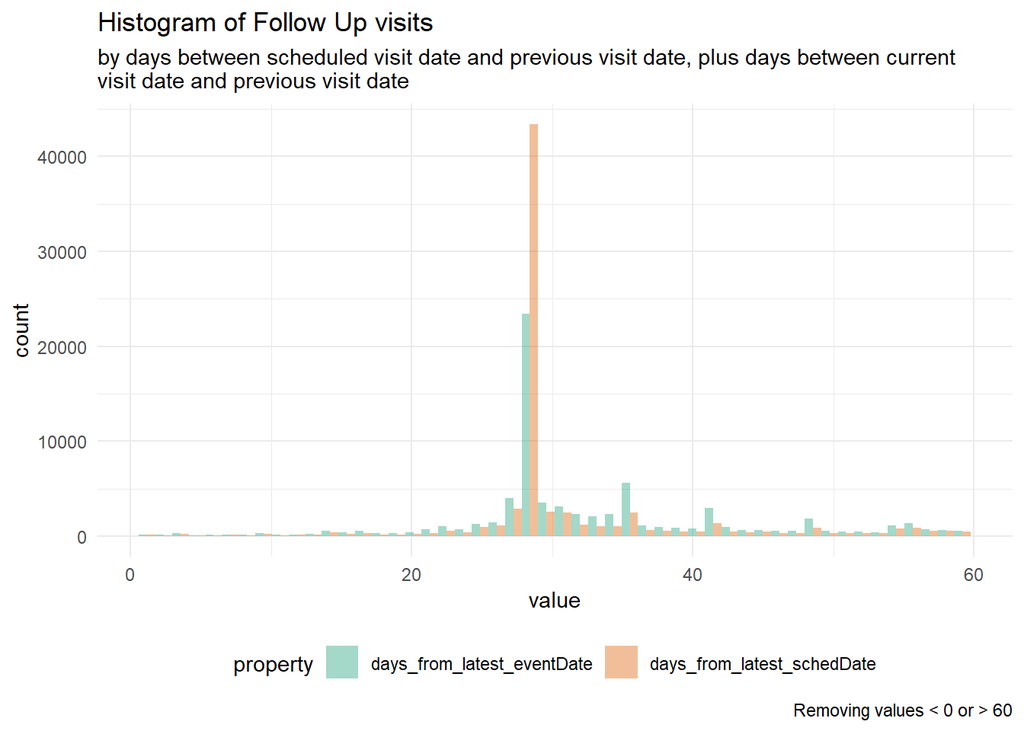

```r
tots %>%
  ungroup() %>%
  filter(appt_tally!=1) %>%
  mutate(days_from_latest_schedDate=as.numeric(scheduled_date-prev_event_date)) %>%
  mutate(days_from_latest_eventDate=as.integer(event_date-prev_event_date)) %>%
  filter(days_from_latest_eventDate<60 & days_from_latest_eventDate>0) %>%
    filter(days_from_latest_schedDate<60& days_from_latest_schedDate>0) %>%
  select(reg_visit_id, starts_with("days_from")) %>%
  pivot_longer(cols=starts_with("days_from"), names_to="property", values_to="value") %>%
ggplot(aes(x=value, fill=property)) +
  # facet_wrap(~property) +
  geom_histogram(position="dodge",alpha=0.4, bins=50) +
  labs(title="Histogram of Follow Up visits",
  subtitle=str_wrap("by days between scheduled visit date and previous visit date, plus days between current visit date and previous visit date", 90),
       caption="Removing values < 0 or > 60") +
  theme(legend.position = "bottom")
```

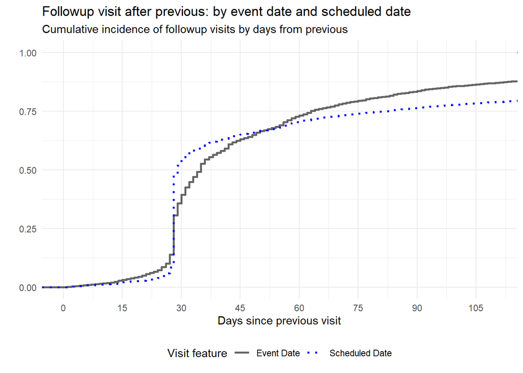

```r
tots %>%
  ungroup() %>%
  filter(appt_tally!=1) %>%
  mutate(days_from_latest_schedDate=as.numeric(scheduled_date-prev_event_date)) %>%
  mutate(days_from_latest_eventDate=as.integer(event_date-prev_event_date)) %>%
  # filter(days_from_latest_eventDate<90 & days_from_latest_eventDate>0) %>%
    filter(days_from_latest_schedDate>0) %>%
  ggplot() +
  geom_step(aes(x=days_from_latest_eventDate,y=after_stat(y), color="Event Date"),
            stat="ecdf", linewidth=1, alpha=0.6) +
  geom_step(aes(x=days_from_latest_schedDate,y=after_stat(y), color="Scheduled Date"),
            stat="ecdf", linetype=3, linewidth=1) +
  labs(title="Followup visit after previous: by event date and scheduled date",
       subtitle="Cumulative incidence of followup visits by days from previous",
       x="Days since previous visit",
       y="") +
      scale_color_manual(name = "Visit feature",
                         values = c("Event Date" = "black", #match the name of the element to the name in the aes
                                    "Scheduled Date" = "blue")) +
  coord_cartesian(xlim = c(0, 110), ylim=c(0,1)) +
  scale_x_continuous(breaks = seq(0, 105, by = 15)) +
  theme(legend.position ="bottom")
```

```r
my_ggsave("fig2_incidence_after_previous",10)
```

53% of followup visits are scheduled to occur 27-36 days after the previous visit, with 38% on precisely 28 days later (the system default scheduled date). 44% of followup visits actually occur within that window.

NEXT STEPS:

- Create the windows for timeliness for each subsequent visit
- Per visit-opportunity analysis of timeliness

## Timely Windows

```r
tots_timely<-tots %>%
  ungroup() %>%
  filter(appt_tally==1 | event_date-prev_event_date>=7) %>% # remove visits within 7 days of last
  mutate(nextdate_37=event_date+37, # create 37 and 90 day windows
         nextdate_90=event_date+90,
         nextdate_37_kept=if_else(lead_event_date<=nextdate_37, 1, 0),
         nextdate_90_kept=if_else(lead_event_date<=nextdate_90, 1, 0)) %>%
  mutate(across(contains("kept"), ~replace(., is.na(.), 0))) %>%
  select(sex, State,appt_tally, total_patient_visits, ncd_patient_status,
         contains("reg"),contains("event_date"), contains("nextdate"), everything())
```

Adding month and year variables to the expected window for subsequent visits, and checking whether patient attended their next visit within that window.

```r
tots_timely<-tots_timely %>%
  mutate(exp_year=lubridate::year(nextdate_90)) %>%
  mutate(exp_month=lubridate::month(nextdate_90)) %>%
  mutate(exp_year_month=make_date(year=exp_year, month=exp_month, day="01")) %>%
  mutate(days_since_last=as.integer(event_date-prev_event_date))
```

## Outcome Events and Censoring Events

This next part is crucial.

The **FIRST** time a patient exceeds 90 days before the next visit, they are LTFU at that 90 day mark.

This is the **OUTCOME EVENT**. Subsequent visits for that patient would be discarded.

IFF a patient is marked **TRANSFERRED** or **DEATH**, then they are *CENSORED* after last visit. IFF the last expected visit is after July 1, then they are *CENSORED* after last visit.

```r
tots_timely<-tots_timely %>%
  arrange(reg_id, appt_tally) %>%
  mutate(nextdate_90_dropout=if_else(nextdate_90_kept==0, 1, NA)) %>%
  group_by(reg_id) %>%
  fill(nextdate_90_dropout, .direction="down") %>%
  mutate(nextdate_90_dropout=replace_na(nextdate_90_dropout, 0)) %>%
  mutate(visits_since_dropout=cumsum(nextdate_90_dropout)) %>% # visit before dropout==1
  ungroup() %>%
  mutate(censor =
    case_when(
      appt_tally==total_patient_visits & ncd_patient_status %in% c("Transferred","Died") ~ 1,
      nextdate_90 > ymd("2024-07-01") ~ 1,
      TRUE ~ 0
    )
  )

tots_timely %>%
  select(reg_id, event_date, days_since_last, appt_tally, visits_since_dropout,
         contains("nextdate_90"), censor) %>% tail(15)
```

```
# A tibble: 15 × 9
   reg_id event_date days_since_last appt_tally visits_since_dropout nextdate_90
    <dbl> <date>               <int>      <dbl>                <dbl> <date>
 1  32329 2022-10-12              21          6                    0 2023-01-10
 2  32329 2022-11-17              36          7                    0 2023-02-15
 3  32329 2023-01-15              59          8                    0 2023-04-15
 4  32329 2023-03-20              64          9                    1 2023-06-18
 5  32329 2023-08-23             156         10                    2 2023-11-21
 6  32329 2024-02-19             180         11                    3 2024-05-19
 7  32331 2023-02-09              NA          1                    0 2023-05-10
 8  32331 2023-03-13              32          2                    0 2023-06-11
 9  32331 2023-05-31              79          3                    0 2023-08-29
10  32331 2023-07-17              47          4                    0 2023-10-15
11  32331 2023-08-21              35          5                    0 2023-11-19
12  32331 2023-09-25              35          6                    0 2023-12-24
13  32331 2023-12-18              84          7                    1 2024-03-17
14  32332 2022-03-31              NA          1                    1 2022-06-29
15  32332 2022-09-29             182          2                    2 2022-12-28
# ℹ 3 more variables: nextdate_90_kept <dbl>, nextdate_90_dropout <dbl>,
#   censor <dbl>
```

```r
tots_timely %>%
  count(censor) %>% kable() %>% kableExtra::kable_styling()
```

| censor | n |
| --- | --- |
| 0 | 150019 |
| 1 | 12319 |

```r
# 12292/(149856+12292)

# tots_timely %>%
#   filter(visits_since_dropout < 2) %>%
#   distinct(reg_id)
```

We can now calculate the **RATES** of attrition.

### Attrition Rate charts

This removes visits that are censored or after dropout.

```r
tots_timely_rates_prep<-tots_timely %>%
   filter(censor==0) %>%
   filter(!is.na(sex)) %>%
   filter(visits_since_dropout<2)
#dropout occurs only once.... and if censored, not included in denom


find_dropout_rates<-function(data, ...){
  data %>%
   group_by(exp_year_month, ...) %>%
   count(nextdate_90_kept) %>%
   mutate(rate= n/sum(n)) %>%
   ungroup()
}

tots_timely_rates_all<-tots_timely_rates_prep %>%
  find_dropout_rates()

tots_timely_rates_all %>%
  group_by(nextdate_90_kept) %>%
  summarise(avg_monthly_rate=mean(rate)) %>% kable() %>% kableExtra::kable_styling()
```

| nextdate_90_kept | avg_monthly_rate |
| --- | --- |
| 0 | 0.2619861 |
| 1 | 0.7380139 |

**The average monthly INCIDENCE RATE of attrition events (dropouts) is 26%**

Now further breakdown of dropout incidence by categories

```r
tots_timely_rates_ss<-tots_timely_rates_prep %>%
    find_dropout_rates(sex, State)

tots_timely_rates_appt_tally<-tots_timely_rates_prep %>%
  filter(appt_tally<6) %>%
  mutate(appt_tally=as.factor(appt_tally)) %>%
  find_dropout_rates(appt_tally)

tots_timely_rates_state_appt_tally<-tots_timely_rates_prep %>%
  filter(appt_tally<5) %>%
  mutate(appt_tally=as.factor(appt_tally)) %>%
  find_dropout_rates(appt_tally, State)

tots_timely_rates_hc <-tots_timely_rates_prep %>%
    add_count(exp_year_month, LGA, HC) %>%
    filter(n>9) %>%
    find_dropout_rates(State, LGA, HC)

tots_timely_rates_lga <-tots_timely_rates_prep %>%
    add_count(exp_year_month, LGA) %>%
    filter(n>9) %>%
    find_dropout_rates(State, LGA)
```

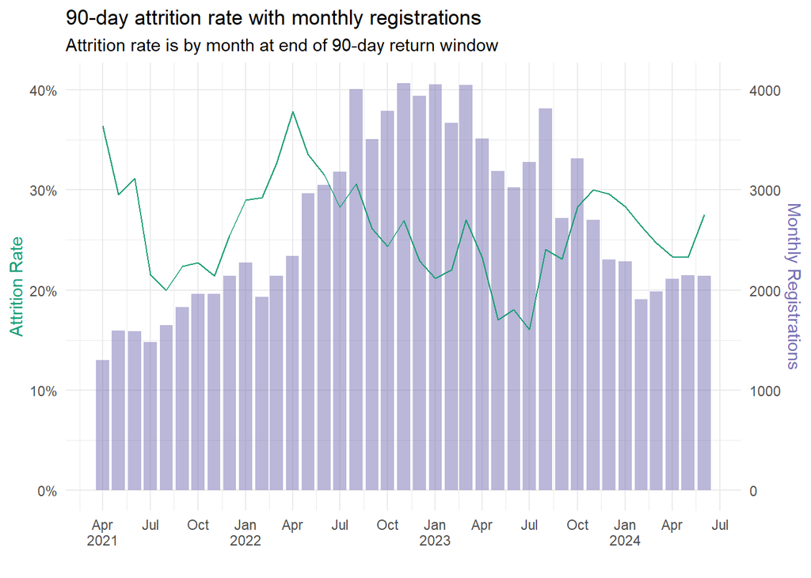

```r
ggcoeff<-10000
ggbarscol<-RColorBrewer::brewer.pal(4,"Dark2")[3]
gglinecol<-RColorBrewer::brewer.pal(4,"Dark2")[1]

attr_90day_withRegs<-tots_timely_rates_prep %>%
  filter(registration_date<=ymd("2024-06-30")) %>%
  # filter(registration_date>=ymd("2021-04-01")) %>%
  # filter(event_date>=ymd("2021-04-01")) %>%
  filter(exp_year_month<=ymd("2024-06-30")) %>%
  mutate(reg_year=lubridate::year(registration_date)) %>%
  mutate(reg_month=lubridate::month(registration_date)) %>%
  mutate(reg_year_month=make_date(year=exp_year,
                                      month=exp_month, day="01")) %>%
  add_count(reg_year_month,name="new_registrations") %>%
  find_dropout_rates(reg_year_month, new_registrations) %>%
  filter(nextdate_90_kept==0) %>%
  ggplot() +
  geom_col(aes(x=reg_year_month, y=new_registrations/ggcoeff),
           fill=ggbarscol, alpha=0.5) +
  geom_line(aes(x=exp_year_month, y=rate), col=gglinecol,stat="identity") +
  labs(title="90-day attrition rate with monthly registrations",
       subtitle="Attrition rate is by month at end of 90-day return window") +
  labs(x="") +
  # theme_classic()+
  theme(legend.position = "bottom",
        axis.title.y.left = element_text(color=gglinecol),
        axis.title.y.right = element_text(color=ggbarscol)) +
  scale_y_continuous(
    name="Attrition Rate",
    labels=scales::label_percent(),
    sec.axis = sec_axis(~.*ggcoeff, name="Monthly Registrations")) +
 scale_x_date(breaks = scales::breaks_pretty(12), labels = scales::label_date_short())


attr_90day_withRegs
```

Remember responses from RTSL here:

- *When were lists of LTFU for outreach generated?* We generated the first list of LTFU for facilities to track patients in April 2021 using the 2021 Q1 NHCI Excel calculator data.
- *When was the dashboard deployed in both states?* March 2022
- *When were legacy data imported?* February 2022
- *When was the DHIS2-only entry pilot started, and was it expanded or ended?* This commenced in August 2023 and ended in December 2023. The pilot just concluded and a report is being written by the consultants. This report would determine how and when we would expand this across the entire program.

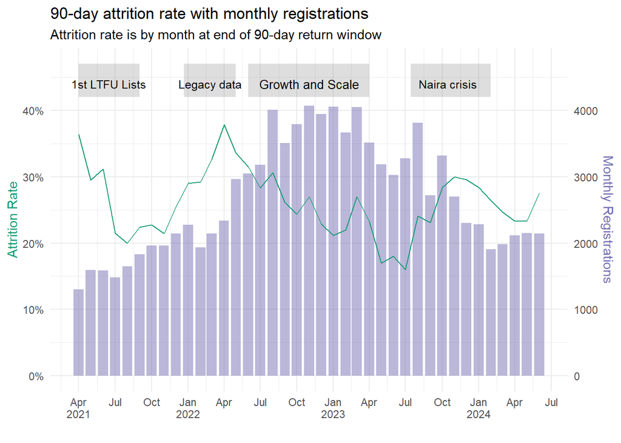

```r
attr_90day_withRegs +
  annotate("rect", xmin = as.Date("2021-04-01"),
                    xmax = as.Date("2021-09-01"),
                    ymin = 0.42, ymax = 0.47, alpha = .2) +
  annotate("rect", xmin = as.Date("2021-12-21"),
                    xmax = as.Date("2022-05-01"),
                    ymin = 0.42, ymax = 0.47, alpha = .2) +
  annotate("rect", xmin = as.Date("2022-06-01"),
                    xmax = as.Date("2023-04-01"),
                    ymin = 0.42, ymax = 0.47, alpha = .2) +
  annotate("rect", xmin = as.Date("2023-07-15"),
                    xmax = as.Date("2024-02-01"),
                    ymin = 0.42, ymax = 0.47, alpha = .2) +
#   geom_text(data = data.frame(x = as.Date("2021-06-01"),
# y = 0.45, label = "1st LTFU List"), mapping = aes(x = x, y = y, label = label),
# size = 2.17, hjust = 0.45, inherit.aes = FALSE)
  annotate("text", x = as.Date("2021-06-15"), y = 0.44,
                  label = "1st LTFU Lists", size=3.3) +
    annotate("text", x = as.Date("2022-02-25"), y = 0.44,
                  label = "Legacy data", size=3.3) +
    annotate("text", x = as.Date("2022-11-01"), y = 0.44,
                  label = "Growth and Scale", size=3.5) +
    annotate("text", x = as.Date("2023-10-15"), y = 0.44,
                  label = "Naira crisis", size=3.3)
```

```r
my_ggsave("fig3_attritionRegs_full", 12)
```

Seasonal trends? Seems to be a dip in spring/summer

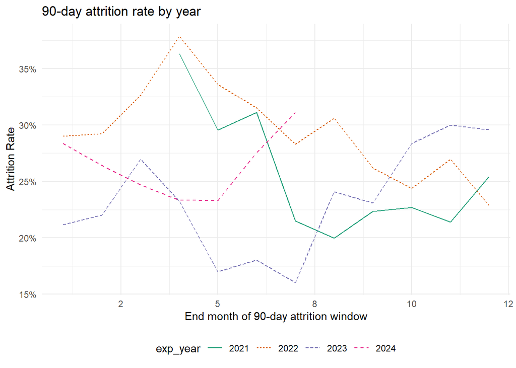

```r
tots_timely_rates_prep %>%
  find_dropout_rates(exp_month, exp_year) %>%
  filter(nextdate_90_kept==0) %>%
    mutate(exp_month=as.integer(exp_month)) %>%
    mutate(exp_year=as.factor(exp_year)) %>%
  ggplot()+
  geom_line(aes(x=exp_month, y=rate,
                color=exp_year, group=exp_year, linetype=exp_year)) +
  labs(title="90-day attrition rate by year") +
  # scale_x_continuous(labels=scales::label_number(accuracy=1)) +
  scale_y_continuous(labels=scales::label_percent()) +
  scale_x_continuous(labels = scales::label_number(accuracy = 1))+
  labs(x="End month of 90-day attrition window",y="Attrition Rate") +
  # theme_classic()+
  theme(legend.position = "bottom")
```

By sex and state

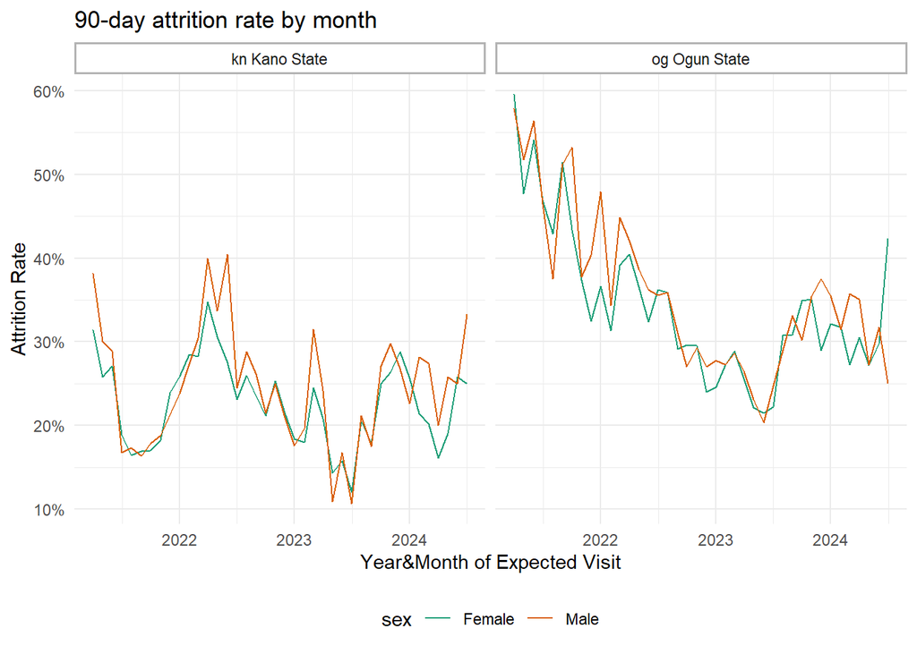

```r
tots_timely_rates_ss %>%
  filter(nextdate_90_kept==0) %>%
  ggplot()+
  geom_line(aes(x=exp_year_month, y=rate, color=sex)) +
  labs(title="90-day attrition rate by month") +
  scale_x_date() +
  facet_grid(~State) +
    scale_y_continuous(labels=scales::label_percent()) +
  labs(x="Year&Month of Expected Visit",y="Attrition Rate") +
  # theme_classic()+
  theme(legend.position = "bottom")
```

```r
# ggsave("attr_90day.jpeg", bg = "transparent", width = 20, height = 10, units = 'cm')
```

By state and appt visit

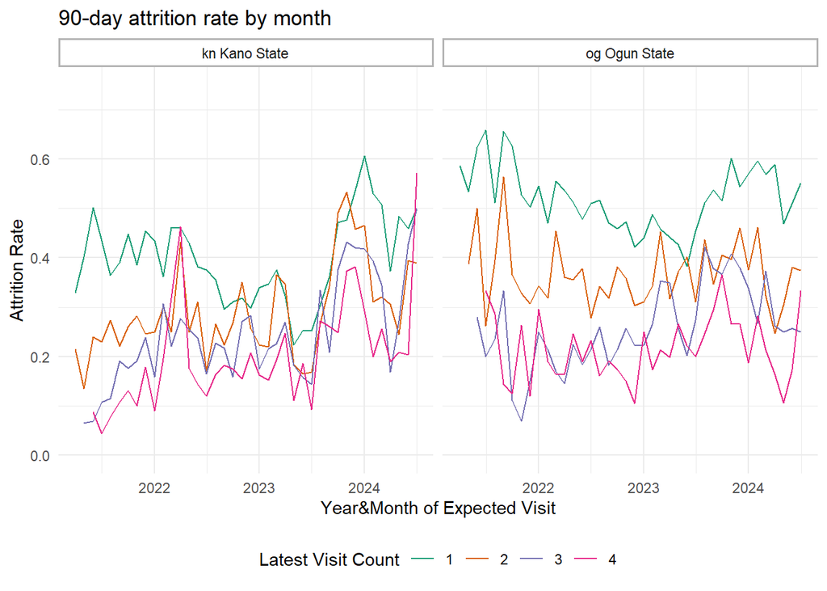

```r
tots_timely_rates_state_appt_tally %>%
  filter(nextdate_90_kept==0) %>%
  ggplot()+
  geom_line(aes(x=exp_year_month, y=rate, color=appt_tally)) +
  labs(title="90-day attrition rate by month") +
  scale_x_date() +
  facet_grid(~State) +
  labs(x="Year&Month of Expected Visit",
       y="Attrition Rate", color="Latest Visit Count") +
  # theme_classic()+
    scale_y_continuous(labels=scales::label_percent()) +
  theme(legend.position = "bottom") +
  scale_y_continuous(limits = c(0, 0.75))
```

```r
# ggsave("attr_90day.jpeg", bg = "transparent", width = 20, height = 10, units = 'cm')
```

Attrition by latest visit number of patient

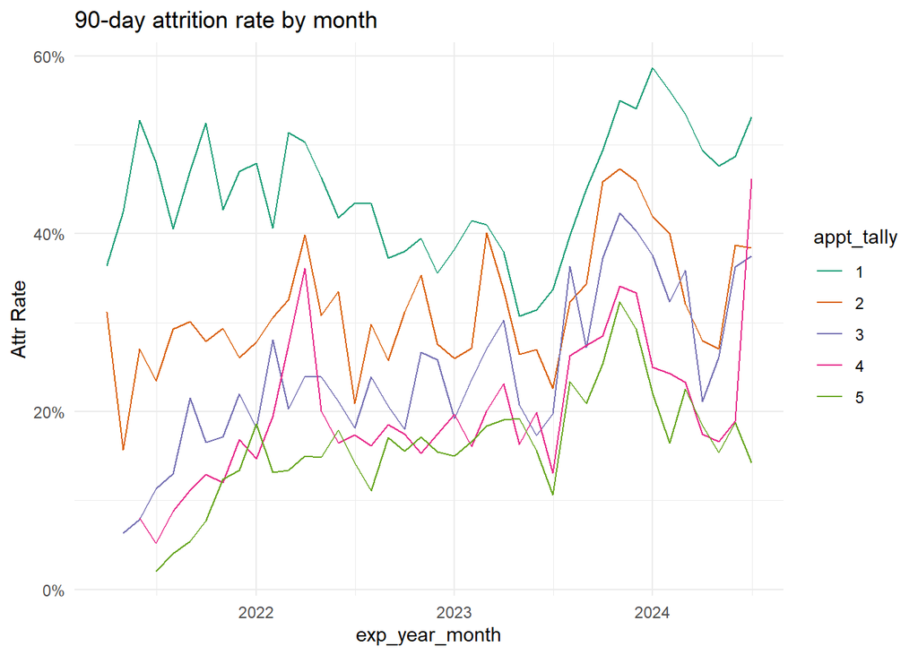

```r
tots_timely_rates_appt_tally %>%
  filter(nextdate_90_kept==0) %>%
  ggplot()+
  geom_line(aes(x=exp_year_month, y=rate, group=appt_tally, color=appt_tally)) +
  scale_y_continuous(labels=scales::label_percent()) +
  labs(title="90-day attrition rate by month", y= "Attr Rate")
```

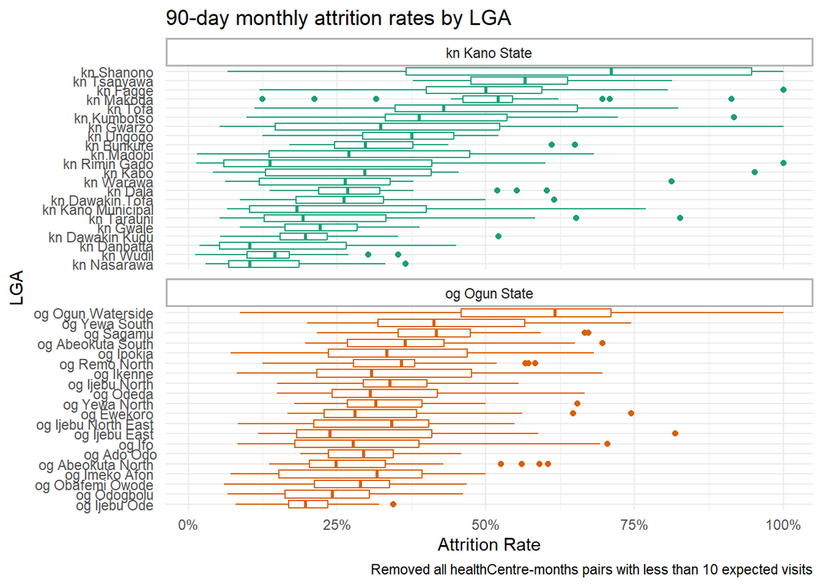

```r
tots_timely_rates_lga %>%
  filter(nextdate_90_kept==0) %>%
  mutate(LGA=str_remove_all(LGA, " Local Government Area")) %>%
  mutate(LGA=fct_reorder(LGA, rate, .fun = mean)) %>%
  ggplot(aes(x = LGA, y = rate, color=State)) +
  geom_boxplot() +
  labs(title="90-day monthly attrition rates by LGA",
       y= "Attrition Rate",
       caption="Removed all healthCentre-months pairs with less than 10 expected visits") +
    facet_wrap(~State, ncol=1, scales="free_y") +
    scale_y_continuous(labels=scales::label_percent()) +
  coord_flip() +
  # theme_classic()
  theme(legend.position = "null")
```

Monthly HC attrition rates

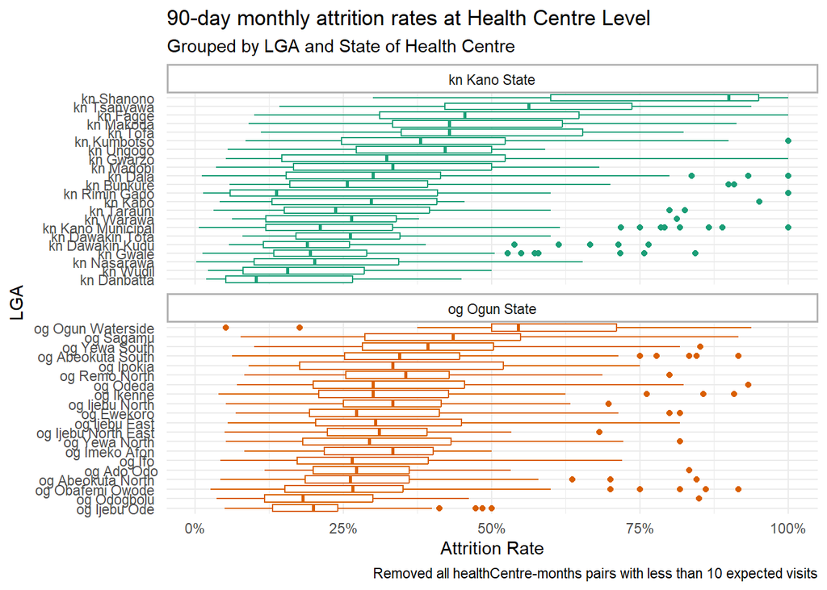

```r
tots_timely_rates_hc %>%
  filter(nextdate_90_kept==0) %>%
  mutate(LGA=str_remove_all(LGA, " Local Government Area")) %>%
  mutate(LGA=fct_reorder(LGA, rate, .fun = mean)) %>%
  ggplot(aes(x = LGA, y = rate, color=State)) +
  geom_boxplot() +
  labs(title="90-day monthly attrition rates at Health Centre Level",
       subtitle="Grouped by LGA and State of Health Centre",
       caption="Removed all healthCentre-months pairs with less than 10 expected visits",
       y= "Attrition Rate") +
    scale_y_continuous(labels=scales::label_percent()) +
    facet_wrap(~State, ncol=1, scales="free_y") +
  coord_flip() +
  # theme_classic() +
  theme(legend.position = "null")
```

Mean and SD

```r
tots_timely_rates_hc %>%
  filter(nextdate_90_kept==0) %>%
  group_by(State) %>%
  summarise(mean=mean(rate),
         sd=sd(rate)) %>%
  kable() %>% kableExtra::kable_styling()
```

| State | mean | sd |
| --- | --- | --- |
| kn Kano State | 0.3293533 | 0.2270595 |
| og Ogun State | 0.3257438 | 0.1767288 |

### Repeat Dropout Patients?

Just to test, what’s the OR for experiencing a dropout for patients who have already experienced one, compared to those who have not?

```r
tots_timely %>%
  select(reg_id, appt_tally, visits_since_dropout, nextdate_90_kept) %>%
  mutate(nextdate_90_notMet=if_else(nextdate_90_kept==1,0,1)) %>%
  mutate(post_dropout=if_else(visits_since_dropout>1, 1, 0)) %>%
  janitor::tabyl(post_dropout,nextdate_90_notMet) %>%
  janitor::adorn_title()
```

```
              nextdate_90_notMet
 post_dropout                  0     1
            0              80519 30573
            1              29441 21805
```

```r
(21858*79526) / (30560*29274)
```

```
[1] 1.943051
```

The odds of dropout at each appointment are 1.94 fold for patients who have previously been delayed more than 90 days and later returned, compared to those who never experienced a first dropout event.

# Proper Treatment Protocol?

Care should follow [national guideline](https://dhis2.org/nigeria-hypertension-control/)

Create a visit variable for each step in the care protocol, if the patient met those criteria and whether the correct meds were offered at the visit.

This could be added to the prediction model.

```r
# Should follow guideline here https://dhis2.org/nigeria-hypertension-control/

tots_timely_quality<-tots_timely %>%
  filter(registration_date>=ymd("2021-01-01")) %>%
    mutate(p_step1_need =
      case_when(
        appt_tally==1  &
        ((bp_systole_mmhg >= 140 & bp_systole_mmhg < 160) |
        (bp_diastole_mmhg >=90 & bp_diastole_mmhg < 100))
        ~ 1,
        TRUE ~ 0
      )) %>%
    mutate(p_step2_need =
      case_when(
        appt_tally==2 & days_since_last >= 14 &
        (bp_systole_mmhg>= 140 |
         bp_diastole_mmhg >=90)
        ~ 1,
        (appt_tally==1  &
        ((bp_systole_mmhg >= 160 & bp_systole_mmhg < 180) |
        (bp_diastole_mmhg >= 100 & bp_diastole_mmhg < 110)))
        ~ 1,
        TRUE ~ 0)
      ) %>%
    mutate(p_step3_need =
      case_when(
        appt_tally==3 & days_since_last >= 14 &
        (bp_systole_mmhg>= 140 |
         bp_diastole_mmhg >=90)
        ~ 1,
        (appt_tally==1  &
        ((bp_systole_mmhg >= 180) |
        (bp_diastole_mmhg >= 110)))
        ~ 1,
        TRUE ~ 0)
      ) %>%
      mutate(p_step4_need =
      case_when(
        appt_tally==4 & days_since_last >= 14 &
        (bp_systole_mmhg>= 140 |
         bp_diastole_mmhg >=90)
        ~ 1,
        TRUE ~ 0)
      ) %>%
  # escalation criteria for first visit
  mutate(p_step2_need=if_else(p_step3_need==1, 0, p_step2_need)) %>%
  mutate(p_step1_need=if_else(p_step2_need==1, 0, p_step1_need)) %>%
  # now do the appropriate treatment for each step
    mutate(p_step1_met =
      case_when(
        p_step1_need==1  & med_amlodipine== "Amlodipine 5mg OD"
        ~ 1,
        TRUE ~ 0)
    ) %>%
    mutate(p_step2_met =
      case_when(
        p_step2_need==1  &
        med_amlodipine== "Amlodipine 5mg OD" &
        (med_losartan=="Losartan 50mg" | (sex=="Female" & age<45))
        ~ 1,
        TRUE ~ 0)
    ) %>%
    mutate(p_step3_met =
      case_when(
        p_step3_need==1  &
        med_amlodipine== "Amlodipine 10mg OD" &
        (med_losartan=="Losartan 100mg" | (sex=="Female" & age<45))
        ~ 1,
        TRUE ~ 0)
    ) %>%
    mutate(p_step4_met =
      case_when(
        p_step4_need==1  &
        med_amlodipine== "Amlodipine 10mg OD" &
        med_hydrochlorothiazide=="Hydrochlorathiazide 25mg" &
        (med_losartan=="Losartan 100mg" | (sex=="Female" & age<45))
        ~ 1,
        TRUE ~ 0)
    )

r2<-function(x){round(x,3)}

tots_timely_quality %>%
  filter(appt_tally<5) %>%
  group_by(nextdate_90_kept) %>%
  summarise(
    p_step1_rate= sum(p_step1_met)/sum(p_step1_need),
    p_step2_rate= sum(p_step2_met)/sum(p_step2_need),
    p_step3_rate= sum(p_step3_met)/sum(p_step3_need),
    p_step4_rate= sum(p_step4_met)/sum(p_step4_need)
  ) %>%
  mutate(across(where(is.double), r2)) %>%
  kable() %>% kableExtra::kable_styling()
```

| nextdate_90_kept | p_step1_rate | p_step2_rate | p_step3_rate | p_step4_rate |
| --- | --- | --- | --- | --- |
| 0 | 0.941 | 0.618 | 0.170 | 0.004 |
| 1 | 0.957 | 0.615 | 0.136 | 0.002 |

While we’re add it, add the change of sBP and DBP since baseline.

This would be a quality indicator too.

```r
tots_timely_quality <- tots_timely_quality %>%
  mutate(bp_systole_mmhg=if_else(bp_systole_mmhg>300, 300, bp_systole_mmhg)) %>%
  mutate(bp_diastole_mmhg=if_else(bp_diastole_mmhg>200, 200, bp_diastole_mmhg)) %>%
  group_by(reg_id) %>%
  mutate(sbp_baseline=if_else(appt_tally==1, bp_systole_mmhg, NA)) %>%
  fill(sbp_baseline, .direction = "down") %>%
  mutate(dbp_baseline=if_else(appt_tally==1, bp_diastole_mmhg, NA)) %>%
  fill(dbp_baseline, .direction = "down") %>%
  ungroup() %>%
  mutate(sbp_change_from_baseline=bp_systole_mmhg-sbp_baseline,
         dbp_change_from_baseline=bp_diastole_mmhg-dbp_baseline)
```

# Weather data

Now add in the daily weather data from open-meteo.com API from 1/1/2021 to 1/7/2024.

This pulled data on max temp, max apparent temp (with humidity), rain total, and rain hours for the centroid coordinates of each LGA.

For details see companion script.

```r
# import weather data and clean the lga names

weather_lga_centroids<-read_rds(here::here("data", "weather_lga_centroids.rds")) %>%
  ungroup() %>%
  mutate(lganame=str_squish(lganame)) %>%
  mutate(lganame=str_remove_all(lganame, "\\/Ota"), # fix this one name
         lganame=str_replace_all(lganame, "Nassarawa","Nasarawa"), # fix this name
         lganame=str_replace_all(lganame, "Dambatta","Danbatta"), # fix this name
         lganame=str_replace_all(lganame, "Shagamu","Sagamu")) %>% # fix this name
  rename_with(~ paste0("cli_", .), max_temp_c:last_col()) %>%
  mutate(lga_37date=str_c(lganame,date,sep="_")) %>%
  arrange(lga_37date) %>%
  select(lga_37date,  starts_with("cli_"))


# clean lga names in main dataset and merge with weather
tots_timely_qual_climate<-tots_timely_quality %>%
    mutate(LGA=str_remove_all(LGA, " Local Government Area ")) %>%
    mutate(LGA=str_sub(LGA, start=4, end=50)) %>%
    mutate(LGA=str_squish(LGA)) %>%
    mutate(lga_37date=str_c(LGA,as.character(nextdate_37),sep="_")) %>%
    arrange(lga_37date) %>%
    left_join(weather_lga_centroids, by="lga_37date")
```

# Market data

Now add in the weekly market data from [FEWSNET API](https://fdw.fews.net/en/) for 1/1/2021 to 1/7/2024

This is official FAO data on food and staple good prices at local markets, and is used to assess food security. The prices are weekly, but have been reformed as a 10 day rolling average.

- Diesel
- Gasoline
- Millet
- Rice (Milled and Broken)
- Maize Grain (Yellow and White)
- Sorghum (Brown and White)
- Yams

According to an [FAO food systems profile on Nigeria](https://openknowledge.fao.org/server/api/core/bitstreams/e5cd1ce0-8d1a-439b-99ad-57b83ef0b4a6/content) (pg 5), these are all staple foods in Nigeria.

The price of oil, both globally and domestically in Nigeria, affects the entire economy, including the price of transportation, staple foods, healthcare, and in general the cost of living. Theses prices could therefore affect ability/willingness to access HTN services.

Note data were not available for Ogun State, but Lagos borders Ogun to the South, and has market data more consistent with national rates than Oyo to the north.

For details see companion script.

```r
fews<-read_rds(here::here("data", "fews_ng_prices_2021_2024.rds")) %>%
    ungroup() %>%
    filter(date>ymd("2021-02-01")) %>%
    rename_with(~ paste0("mkt_", .), 3:last_col()) %>%
    mutate(admin_1=if_else(admin_1=="Lagos", "Ogun","Kano")) %>%
      arrange(admin_1, date) %>%
    mutate(state_37date=str_c(admin_1,date,sep="_")) %>%
    select(state_37date, starts_with("mkt")) %>%
    arrange(state_37date)


tots_timely_qual_cli_mkt<-tots_timely_qual_climate %>%
    # clean up state name to merge with market prices
    arrange(State, nextdate_37) %>%
    mutate(State=str_remove_all(State, " State"),
           State=str_sub(State, 5, 50),
           State=str_squish(State)) %>%
    mutate(state_37date=str_c(State,nextdate_37,sep="_")) %>%
    arrange(state_37date) %>%
    left_join(fews, by="state_37date") %>%
    select(reg_id, reg_visit_id, registration_date, #reorder some vars
           event_date, appt_tally, everything())
```

Are weather and market prices 28-37 days after latest visit different for those who attend their next one 0-37 days after that visit, and those who fail to attend?

Ttest and effect sizes might give a general idea…

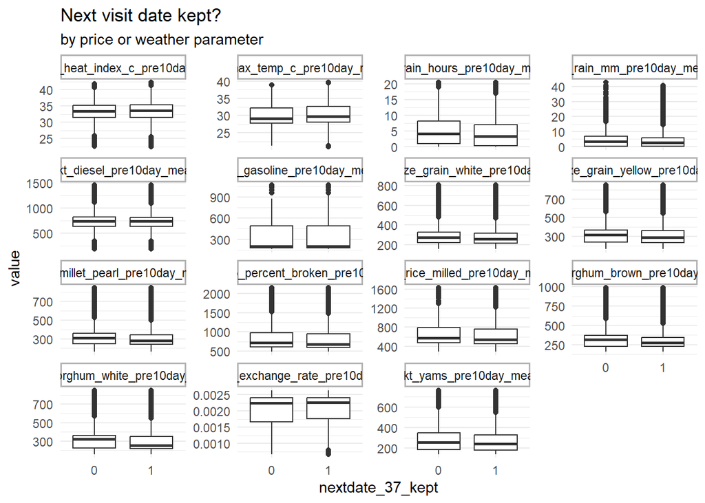

```r
pop_params_dropouts_37days_prep<-tots_timely_qual_cli_mkt %>%
   filter(censor==0) %>%
   filter(visits_since_dropout<1) %>%
  # removed censored obs or those that already "droppedout"
  mutate(nextdate_37_kept=as.factor(nextdate_37_kept)) %>%
  select(State, nextdate_37_kept, ends_with("pre10day_mean")) %>%
  rowid_to_column() %>%
  pivot_longer(cols=ends_with("pre10day_mean"),
               names_to="var",
               values_to="value")

# boxplot
pop_params_dropouts_37days_prep %>%
  ggplot() +
    aes(x = nextdate_37_kept,
        y = value) +
    geom_boxplot() +
    facet_wrap(~var, scales = "free_y") +

    labs(title="Next visit date kept?",
         subtitle="by price or weather parameter")
```

```r
# pvalues
pop_params_pvalues<-pop_params_dropouts_37days_prep %>%
    group_by(var) %>%
    reframe(t_test = list(t.test(value ~ nextdate_37_kept, data = cur_data()))) %>%
    mutate(tidy_result = map(t_test, broom::tidy)) %>%
    unnest(tidy_result)

# effect sizes
pop_params_effect_sizes <- pop_params_dropouts_37days_prep %>%
  group_by(var) %>%
  reframe(cohens_d = cohens_d(value ~ nextdate_37_kept, data = cur_data())) %>%
  unnest("cohens_d")

pop_params_pvalues %>% select(var, estimate, p.value)
```

```
# A tibble: 15 × 3
   var                                        estimate  p.value
   <chr>                                         <dbl>    <dbl>
 1 cli_max_heat_index_c_pre10day_mean      -0.102      7.57e- 6
 2 cli_max_temp_c_pre10day_mean            -0.422      2.80e-61
 3 cli_rain_hours_pre10day_mean             0.693      3.85e-77
 4 cli_rain_mm_pre10day_mean                0.635      4.67e-72
 5 mkt_diesel_pre10day_mean                25.6        1.28e-31
 6 mkt_gasoline_pre10day_mean              -1.18       4.26e- 1
 7 mkt_maize_grain_white_pre10day_mean     11.8        2.09e-27
 8 mkt_maize_grain_yellow_pre10day_mean    13.2        9.55e-32
 9 mkt_millet_pearl_pre10day_mean          16.2        5.99e-44
10 mkt_rice_5_percent_broken_pre10day_mean 32.5        7.39e-35
11 mkt_rice_milled_pre10day_mean           30.8        1.17e-48
12 mkt_sorghum_brown_pre10day_mean         18.1        5.87e-39
13 mkt_sorghum_white_pre10day_mean         19.0        3.87e-50
14 mkt_usd_exchange_rate_pre10day_mean     -0.00000936 3.40e- 2
15 mkt_yams_pre10day_mean                   9.80       3.21e-17
```

```r
pop_params_effect_sizes
```

```
# A tibble: 15 × 5
   var                                     Cohens_d    CI  CI_low  CI_high
   <chr>                                      <dbl> <dbl>   <dbl>    <dbl>
 1 cli_max_heat_index_c_pre10day_mean      -0.0353   0.95 -0.0510 -0.0195
 2 cli_max_temp_c_pre10day_mean            -0.131    0.95 -0.147  -0.115
 3 cli_rain_hours_pre10day_mean             0.153    0.95  0.137   0.168
 4 cli_rain_mm_pre10day_mean                0.148    0.95  0.133   0.164
 5 mkt_diesel_pre10day_mean                 0.0908   0.95  0.0750  0.107
 6 mkt_gasoline_pre10day_mean              -0.00636  0.95 -0.0221  0.00939
 7 mkt_maize_grain_white_pre10day_mean      0.0893   0.95  0.0735  0.105
 8 mkt_maize_grain_yellow_pre10day_mean     0.0961   0.95  0.0804  0.112
 9 mkt_millet_pearl_pre10day_mean           0.115    0.95  0.0995  0.131
10 mkt_rice_5_percent_broken_pre10day_mean  0.102    0.95  0.0858  0.117
11 mkt_rice_milled_pre10day_mean            0.120    0.95  0.104   0.136
12 mkt_sorghum_brown_pre10day_mean          0.109    0.95  0.0934  0.125
13 mkt_sorghum_white_pre10day_mean          0.124    0.95  0.109   0.140
14 mkt_usd_exchange_rate_pre10day_mean     -0.0170   0.95 -0.0328 -0.00128
15 mkt_yams_pre10day_mean                   0.0673   0.95  0.0515  0.0830
```

```r
# use these for the model
pop_params_top<-pop_params_effect_sizes %>% filter(abs(Cohens_d)>0.11) %>% pluck("var")
print(paste0("Consider these vars for model: ", str_c(pop_params_top, collapse =', ')))
```

```
[1] "Consider these vars for model: cli_max_temp_c_pre10day_mean, cli_rain_hours_pre10day_mean, cli_rain_mm_pre10day_mean, mkt_millet_pearl_pre10day_mean, mkt_rice_milled_pre10day_mean, mkt_sorghum_white_pre10day_mean"
```

```r
readr::write_lines(pop_params_top, "cli_mkt_params_for_model.txt")
```

A t test is performed across all these pop level parameters, to test if between the means of the parameters differ where the next visit is a success or failure (success defined as Next Visit =< 37 days from current visit).

All price and weather parameters have a small pvalue, except the price of gasoline.

However, the effect sizes (cohens d) are small for all parameters. Max temp, rain total, rain hours, millet, rice, and sorghum price, price have the highest effect sizes (>0.11). Max temp has an inverse association than expected (more attendance on comparatively hot days).

For greater effect size, may need to respecify. For example, instead of using 10 day averages, use precise weather variables on the date 28 days after latest appointment, with an outcome of visiting on that exact day.

Here is an example: for a given 10 day window, is the average price of milled rice at state level related to the rate of patients returning for subsequent visits within that 10 day window?

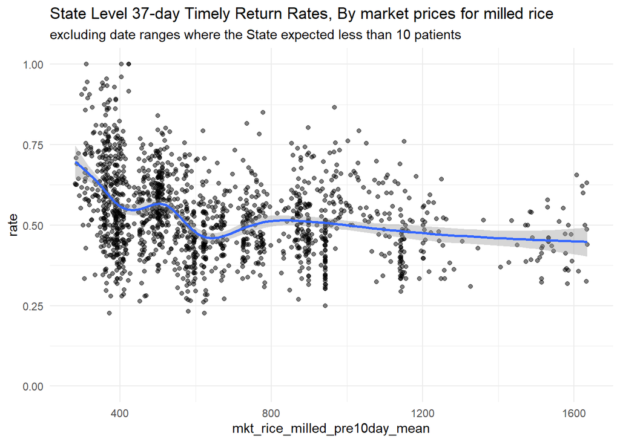

```r
tots_timely_rates_prep_detailed<-tots_timely_qual_cli_mkt %>%
   filter(censor==0) %>%
   filter(!is.na(sex)) %>%
   filter(visits_since_dropout<2)
#dropout occurs only once.... and if censored, not included in denom


find_dropout_rates_detailed <-function(data, ...){
  data %>%
  mutate(nextdate_37_kept=factor(nextdate_37_kept, levels=c(0,1))) %>%
  group_by(nextdate_37, ...) %>%
  count(nextdate_37_kept) %>%
  mutate(rate=n/sum(n)) %>%
  ungroup() %>%
  filter(nextdate_37_kept==1)
}

tots_timely_rates_prep_detailed %>%
  find_dropout_rates_detailed(State, mkt_rice_milled_pre10day_mean) %>%
  filter(n>9) %>%
  ggplot(aes(x=mkt_rice_milled_pre10day_mean, y=rate)) +
  geom_jitter( alpha=0.5)+
  geom_smooth() +
  expand_limits(y = c(0, 1)) +
  labs(title="State Level 37-day Timely Return Rates, By market prices for milled rice",
       subtitle="excluding date ranges where the State expected less than 10 patients")
```

# Review and Save data

In a final review, check distributions of all the vars.

```r
dfs<-tots_timely_qual_cli_mkt %>%
  summarytools::dfSummary(plain.ascii = FALSE,stile="grid",
                          max.string.width=15)

dfs$Variable <- gsub("_", " ", dfs$Variable)

print(dfs, method="render", varnumbers   = FALSE,
                valid.col    = FALSE,max.tbl.width = 40,
      caption="Removing _underscores_ from varnames for space")
```

Data Frame Summary

tots_timely_qual_cli_mkt

**Dimensions**: 153413 x 107  
**Duplicates**: 0

| **Variable** | **Stats / Values** | **Freqs (% of Valid)** | **Graph** | **Missing** |
| --- | --- | --- | --- | --- |
| reg id [numeric] | Mean (sd) : 16102.7 (9361.3) min ≤ med ≤ max: 0 ≤ 16067 ≤ 32332 IQR (CV) : 16258 (0.6) | 29667 distinct values |  | 0 (0.0%) |
| reg visit id [character] | 1. 10209_1 2. 10224_3 3. 10528_4 4. 10916_4 5. 10976_5 6. 11008_6 7. 11129_19 8. 11245_10 9. 11257_5 10. 11371_24 [ 153227 others ] | 2 ( 0.0% ) 2 ( 0.0% ) 2 ( 0.0% ) 2 ( 0.0% ) 2 ( 0.0% ) 2 ( 0.0% ) 2 ( 0.0% ) 2 ( 0.0% ) 2 ( 0.0% ) 2 ( 0.0% ) 153393 ( 100.0% ) |  | 0 (0.0%) |
| registration date [Date] | min : 2021-01-01 med : 2022-05-10 max : 2024-07-01 range : 3y 6m 0d | 1246 distinct values |  | 0 (0.0%) |
| event date [Date] | min : 2021-01-01 med : 2023-01-23 max : 2024-07-01 range : 3y 6m 0d | 1278 distinct values |  | 0 (0.0%) |
| appt tally [numeric] | Mean (sd) : 6 (5.5) min ≤ med ≤ max: 1 ≤ 4 ≤ 45 IQR (CV) : 6 (0.9) | 45 distinct values |  | 0 (0.0%) |
| sex [character] | 1. Female 2. Male | 117013 ( 76.3% ) 36357 ( 23.7% ) |  | 43 (0.0%) |
| State [character] | 1. Kano 2. Ogun | 97605 ( 63.6% ) 55808 ( 36.4% ) |  | 0 (0.0%) |
| total patient visits [integer] | Mean (sd) : 11 (7.9) min ≤ med ≤ max: 1 ≤ 9 ≤ 45 IQR (CV) : 11 (0.7) | 42 distinct values |  | 0 (0.0%) |
| ncd patient status [character] | 1. Active record 2. Died 3. Inactive record 4. Transferred 5. Unresponsive | 151920 ( 99.0% ) 452 ( 0.3% ) 424 ( 0.3% ) 548 ( 0.4% ) 69 ( 0.0% ) |  | 0 (0.0%) |
| prev event date [Date] | min : 2021-01-01 med : 2022-12-22 max : 2024-06-24 range : 3y 5m 23d | 1264 distinct values |  | 29690 (19.4%) |
| lead event date [Date] | min : 2021-01-04 med : 2023-03-09 max : 2024-07-01 range : 3y 5m 27d | 1259 distinct values |  | 29543 (19.3%) |
| nextdate 37 [Date] | min : 2021-02-07 med : 2023-03-01 max : 2024-08-07 range : 3y 6m 0d | 1278 distinct values |  | 0 (0.0%) |
| nextdate 90 [Date] | min : 2021-04-01 med : 2023-04-23 max : 2024-09-29 range : 3y 5m 28d | 1278 distinct values |  | 0 (0.0%) |
| nextdate 37 kept [numeric] | Min : 0 Mean : 0.4 Max : 1 | 0 : 85159 ( 55.5% ) 1 : 68254 ( 44.5% ) |  | 0 (0.0%) |
| nextdate 90 kept [numeric] | Min : 0 Mean : 0.7 Max : 1 | 0 : 50260 ( 32.8% ) 1 : 103153 ( 67.2% ) |  | 0 (0.0%) |
| stored by [character] | 1. Jaen_PHC 2. Gwagwarwa_PHC 3. Hotoro_NorthPHC 4. Kabuga_PHC 5. Okeilewo_FHC 6. Dawakindakata_P 7. Gano_PHC 8. Dala_PHC 9. Sheka_PHC 10. akumbabarns [ 97 others ] | 7268 ( 6.9% ) 7157 ( 6.8% ) 6519 ( 6.2% ) 4464 ( 4.2% ) 4031 ( 3.8% ) 3825 ( 3.6% ) 3721 ( 3.5% ) 3651 ( 3.4% ) 3176 ( 3.0% ) 2498 ( 2.4% ) 59616 ( 56.3% ) |  | 47487 (31.0%) |
| created by [character] | 1. Akumba, Barnaba 2. DAKATA, NASSARA 3. Recorder, GWAGW 4. Recorder, JAEN 5. Recorder, HOTOR 6. Okeilewo, FHC ( 7. Recorder, KABUG 8. Recorder, GANO 9. Recorder, SHEKA 10. Recorder, DALA [ 96 others … | 15970 ( 10.4% ) 8352 ( 5.4% ) 8036 ( 5.2% ) 7569 ( 4.9% ) 6092 ( 4.0% ) 5142 ( 3.4% ) 4556 ( 3.0% ) 3477 ( 2.3% ) 3082 ( 2.0% ) 2926 ( 1.9% ) 88211 ( 57.5% ) |  | 0 (0.0%) |
| last updated by [character] | 1. Recorder, JAEN 2. Recorder, HOTOR 3. Recorder, GWAGW 4. DAKATA, NASSARA 5. Recorder, KABUG 6. Okeilewo, FHC ( 7. Recorder, GANO 8. Recorder, DALA 9. Recorder, SHEKA 10. Olose, PHC (Olo [ 97 others … | 9574 ( 6.2% ) 9085 ( 5.9% ) 9063 ( 5.9% ) 8352 ( 5.4% ) 5544 ( 3.6% ) 5496 ( 3.6% ) 4377 ( 2.9% ) 4030 ( 2.6% ) 3429 ( 2.2% ) 3209 ( 2.1% ) 91254 ( 59.5% ) |  | 0 (0.0%) |
| last updated on [Date] | min : 2021-01-02 med : 2023-06-10 max : 2024-07-21 range : 3y 6m 19d | 1265 distinct values |  | 0 (0.0%) |
| scheduled date [Date] | min : 1974-06-12 med : 2023-03-31 max : 2201-08-29 range : 227y 2m 17d | 1331 distinct values |  | 0 (0.0%) |
| incident date [Date] | min : 2003-12-08 med : 2022-06-14 max : 2024-07-17 range : 20y 7m 9d | 1233 distinct values |  | 0 (0.0%) |
| organisation unit name [character] | 1. kn Ja'En Primar 2. kn Hotoro Arewa 3. kn Gwagwarwa Pr 4. kn Dawakin Daka 5. kn Kabuga Prima 6. og Oke Ilewo Fa 7. kn Gano Primary 8. kn Dala Primary 9. kn Shekar Barde 10. og Olose Primar [ 94 othe… | 9816 ( 6.4% ) 9691 ( 6.3% ) 9293 ( 6.1% ) 8352 ( 5.4% ) 5736 ( 3.7% ) 5519 ( 3.6% ) 4539 ( 3.0% ) 4193 ( 2.7% ) 3748 ( 2.4% ) 3271 ( 2.1% ) 89255 ( 58.2% ) |  | 0 (0.0%) |
| Nat [character] | 1. fg Nigeria · | 153413 ( 100.0% ) |  | 0 (0.0%) |
| LGA [character] | 1. Nasarawa 2. Gwale 3. Dala 4. Abeokuta South 5. Kano Municipal 6. Kumbotso 7. Ifo 8. Abeokuta North 9. Dawakin Kudu 10. Tsanyawa [ 32 others ] | 27813 ( 18.1% ) 15552 ( 10.1% ) 9870 ( 6.4% ) 8028 ( 5.2% ) 5888 ( 3.8% ) 5852 ( 3.8% ) 5312 ( 3.5% ) 4978 ( 3.2% ) 4927 ( 3.2% ) 4809 ( 3.1% ) 60384 ( 39.4% ) |  | 0 (0.0%) |
| Ward [character] | 1. · kn Dorayi Ward 2. · kn Hotoro Nort 3. · kn Gawuna Ward 4. · kn Dakata Ward 5. · kn Kabuga Ward 6. · og Oke-Ilewo W 7. · kn Gano Ward · 8. · kn Kabuwaya Wa 9. · kn Dan Maliki 10. Ota Local Gover [… | 9816 ( 6.4% ) 9691 ( 6.3% ) 9293 ( 6.1% ) 8352 ( 5.4% ) 5736 ( 3.7% ) 5519 ( 3.6% ) 4539 ( 3.0% ) 4193 ( 2.7% ) 3749 ( 2.4% ) 3576 ( 2.3% ) 88949 ( 58.0% ) |  | 0 (0.0%) |
| HC [character] | 1. · kn Ja'En Prima 2. · kn Hotoro Arew 3. · kn Gwagwarwa P 4. · kn Dawakin Dak 5. · kn Kabuga Prim 6. · og Oke Ilewo F 7. · kn Gano Primar 8. · kn Dala Primar 9. · kn Shekar Bard 10. · og Olose Prima… | 9816 ( 6.4% ) 9691 ( 6.3% ) 9293 ( 6.1% ) 8352 ( 5.4% ) 5736 ( 3.7% ) 5519 ( 3.6% ) 4539 ( 3.0% ) 4193 ( 2.7% ) 3748 ( 2.4% ) 3271 ( 2.1% ) 89255 ( 58.2% ) |  | 0 (0.0%) |
| FACILITY [character] | 1. · og Agbara Prim 2. · og Ajuwon Prim 3. · og Alagbon Hea 4. · og Igbogila Pr 5. · og Keesi Prima 6. · og Mobalufon M 7. · og Oke-Oyinbo 8. · og Otta Primar 9. · og Owode Healt 10. · og Sango Prima | 213 ( 2.5% ) 398 ( 4.6% ) 651 ( 7.6% ) 1019 ( 11.8% ) 1209 ( 14.1% ) 657 ( 7.6% ) 898 ( 10.4% ) 1812 ( 21.1% ) 193 ( 2.2% ) 1551 ( 18.0% ) |  | 144812 (94.4%) |
| program status [character] | 1. ACTIVE 2. CANCELLED 3. COMPLETED | 152913 ( 99.7% ) 450 ( 0.3% ) 50 ( 0.0% ) |  | 0 (0.0%) |
| event status [character] | 1. ACTIVE 2. COMPLETED | 3659 ( 2.4% ) 149754 ( 97.6% ) |  | 0 (0.0%) |
| organisation unit [character] | 1. ehJsDey0nF2 2. DxfVRX9j8np 3. xUORgwU22YU 4. jpPaQTbjIlU 5. aoOPscxu7Tc 6. S84LuOwGZ6R 7. bYamdI7FHE5 8. JJL8Ukh1ZlZ 9. uRzXjHHigm9 10. PKf7VHpxmBG [ 95 others ] | 9816 ( 6.4% ) 9691 ( 6.3% ) 9293 ( 6.1% ) 8352 ( 5.4% ) 5736 ( 3.7% ) 5519 ( 3.6% ) 4539 ( 3.0% ) 4193 ( 2.7% ) 3748 ( 2.4% ) 3271 ( 2.1% ) 89255 ( 58.2% ) |  | 0 (0.0%) |

[output cut: 77 more lines]

Generated by summarytools 1.0.1 ([R](https://www.r-project.org/) version 4.3.3)  
2024-08-27

```r
# dhis_subset %>% skimr::skim()

# dhis_clean %>%
#   select(newage, reg_id) %>%
#   distinct() %>%
#   mutate(newage=as.numeric(newage)) %>%
#   skimr::skim()
```

```r
readr::write_rds(tots_timely_qual_cli_mkt,
                 here::here("data","tots_timely_qual_cli_mkt.rds"))
```